# Analysis of Cell Technology

3 competing cell technologies may claim marketshare in future; Bifacial PERC, bifacial SHJ, and Bifacial TOPCon. Each design has different efficiency and a different silver intensity. This analysis seeks compare these technologies on a mass and energy basis. A psuedo global deployment projection hitting 100% RE targets in 2050 is used so that silver demand can be evaluated at the global level.

Make 4+ scenarios

1. All PERC
2. All SHJ
3. All TOPCon
4. Realistic blend / ITRPV numbers from Martin Springer or Jarett Zuboy – DURAMat tech scounting report
5. All of the above and turn Bifacial ON/OFF

We will use the silver intensity and module efficiency projections from:

```
Zhang, Yuchao, Moonyong Kim, Li Wang, Pierre Verlinden, and Brett Hallam. 2021. “Design Considerations for Multi-Terawatt Scale Manufacturing of Existing and Future Photovoltaic Technologies: Challenges and Opportunities Related to Silver, Indium and Bismuth Consumption.” Energy & Environmental Science. https://doi.org/10.1039/D1EE01814K.
```

and

```
Gervais, Estelle, Shivenes Shammugam, Lorenz Friedrich, and Thomas Schlegl. 2021. “Raw Material Needs for the Large-Scale Deployment of Photovoltaics – Effects of Innovation-Driven Roadmaps on Material Constraints until 2050.” Renewable and Sustainable Energy Reviews 137 (March): 110589. https://doi.org/10.1016/j.rser.2020.110589.
```

```python
import numpy as np
import pandas as pd
import os,sys
from pathlib import Path
import matplotlib.pyplot as plt

plt.rcParams.update({'font.size': 18})
#plt.rcParams['figure.figsize'] = (10, 6)

cwd = os.getcwd() #grabs current working directory

testfolder = str(Path().resolve().parent.parent / 'PV_ICE' / 'TEMP' / 'CellTechCompare')
inputfolder = str(Path().resolve().parent.parent / 'PV_ICE' / 'TEMP')
baselinesfolder = str(Path().resolve().parent.parent /'PV_ICE' / 'baselines')
supportMatfolder = str(Path().resolve().parent.parent / 'PV_ICE' / 'baselines' / 'SupportingMaterial')

if not os.path.exists(testfolder):
    os.makedirs(testfolder)
```

# Data Preparation

Bring in the data from Zhang et al 2021 and Gervais et al 2021.

```python
lit_celltech = pd.read_excel(os.path.join(supportMatfolder,'CellTechCompare','PERCvSHJvTOPCon-LitData.xlsx'), sheet_name='Sheet2',
                             header=[0,1,2], index_col=0)
```

```python
lit_celltech.columns.get_level_values
```

```
<bound method MultiIndex.get_level_values of MultiIndex([('Zhang et al 2021 (hallam)',   'PERC',  'ModuleEff'),
            ('Zhang et al 2021 (hallam)',   'PERC', 'Ag_mgpcell'),
            ('Zhang et al 2021 (hallam)',    'SHJ',  'ModuleEff'),
            ('Zhang et al 2021 (hallam)',    'SHJ', 'Ag_mgpcell'),
            ('Zhang et al 2021 (hallam)', 'TOPCon',  'ModuleEff'),
            ('Zhang et al 2021 (hallam)', 'TOPCon', 'Ag_mgpcell')],
           names=[None, None, 'year'])>
```

```python
#Zhang et al Table 2 gives cell size assumptions 166mm cells
cell_size_m2 = np.square(0.166)
```

```python
#calculate silver use per meter squared for each tech
zhang_perc_Ag_gpm2 = lit_celltech['Zhang et al 2021 (hallam)']['PERC']['Ag_mgpcell']/1000/cell_size_m2 #creates series
zhang_shj_Ag_gpm2 = lit_celltech['Zhang et al 2021 (hallam)']['SHJ']['Ag_mgpcell']/1000/cell_size_m2
zhang_topcon_Ag_gpm2 = lit_celltech['Zhang et al 2021 (hallam)']['TOPCon']['Ag_mgpcell']/1000/cell_size_m2
```

Gervais et al 2021 also project silver use, but through 2050. We wil use Zhang et al silver intensity through 2030, then a futher decrease from Gervais et al to 2050. There is no projection of TOPCon from Gervais et al, so we will assume a similar magnitude of continued decrease.

```python
lit_celltech.loc[2030]
```

```
                                   year
Zhang et al 2021 (hallam)  PERC    ModuleEff     24.5
                                   Ag_mgpcell    57.0
                           SHJ     ModuleEff     25.3
                                   Ag_mgpcell    99.0
                           TOPCon  ModuleEff     25.0
                                   Ag_mgpcell    95.0
Name: 2030, dtype: float64
```

```python
Gervais_perc_2050 = pd.Series({2050:40}) #mg/cell
Gervais_shj_2050 = pd.Series({2050:80}) #mg/cell
guess_topcon_2050 = pd.Series({2050:(95-18)}) # mg/cell 99-80 = 19, 57-40 = 17, guess further 18mg decrease
#assuming the same cell size as Zhang et al (it isn't specified in Gervais)
Gervais_perc_2050_gpm2 = Gervais_perc_2050/1000/cell_size_m2
Gervais_shj_2050_gpm2 = Gervais_shj_2050/1000/cell_size_m2
guess_topcon_2050_gpm2 = guess_topcon_2050/1000/cell_size_m2
```

```python
perc_Ag_gpm2 = pd.concat([zhang_perc_Ag_gpm2.loc[:2049], Gervais_perc_2050_gpm2])
shj_Ag_gpm2 = pd.concat([zhang_shj_Ag_gpm2.loc[:2049], Gervais_shj_2050_gpm2])
topcon_Ag_gpm2 = pd.concat([zhang_topcon_Ag_gpm2.loc[:2049], guess_topcon_2050_gpm2])
```

```python
#filled projections 2020 through 2050
perc_Ag_gpm2.interpolate(inplace=True)
shj_Ag_gpm2.interpolate(inplace=True)
topcon_Ag_gpm2.interpolate(inplace=True)
```

Now lets use Zhang et al's projections of efficiency increases. These are reasonably ambitious, achieving ~25% by 2030, but PV is usually an overachiever. We will hold efficiency constant after 2030.

```python
zhang_perc_modeff = lit_celltech['Zhang et al 2021 (hallam)']['PERC']['ModuleEff']
zhang_shj_modeff = lit_celltech['Zhang et al 2021 (hallam)']['SHJ']['ModuleEff']
zhang_topcon_modeff = lit_celltech['Zhang et al 2021 (hallam)']['TOPCon']['ModuleEff']
```

```python
zhang_perc_modeff.interpolate(inplace=True)
zhang_shj_modeff.interpolate(inplace=True)
zhang_topcon_modeff.interpolate(inplace=True)
```

```python
modeffs = pd.concat([zhang_perc_modeff,zhang_shj_modeff,zhang_topcon_modeff], axis=1)
modeffs.columns=['PERC','SHJ','TOPCon']
Aguse = pd.concat([perc_Ag_gpm2,shj_Ag_gpm2,topcon_Ag_gpm2], axis=1)
Aguse.columns=['PERC','SHJ','TOPCon']

#print for use in other journals
modeffs.to_csv(os.path.join(supportMatfolder, 'output-celltech-modeffimprovements.csv'))
Aguse.to_csv(os.path.join(supportMatfolder, 'output-celltech-Agusageimprovements.csv'))
```

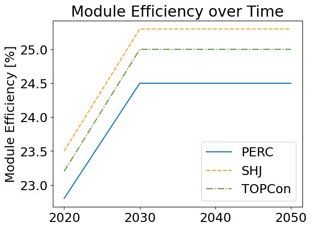

```python
plt.plot(modeffs.index, modeffs['PERC'], color='#0079C2')
plt.plot(modeffs.index, modeffs['SHJ'], color='#F7A11A', ls='--')
plt.plot(modeffs.index, modeffs['TOPCon'], color='#5D9732', ls='-.')

plt.legend(modeffs.columns)
plt.title('Module Efficiency over Time')
plt.ylabel('Module Efficiency [%]')
#plt.rc('font', size=20) #controls default text size
#plt.rc('axes', titlesize=10) #fontsize of the title
#plt.rc('axes', labelsize=10) #fontsize of the x and y labels
#plt.rc('xtick', labelsize=10) #fontsize of the x tick labels
#plt.rc('ytick', labelsize=10) #fontsize of the y tick labels
#plt.rc('legend', fontsize=10) #fontsize of the legend
#plt.show()
```

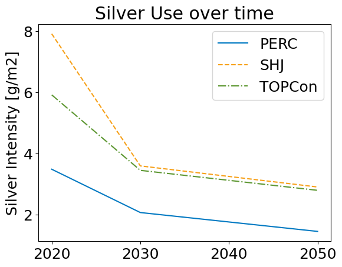

```python
plt.plot(Aguse.index, Aguse['PERC'], color='#0079C2')
plt.plot(Aguse.index, Aguse['SHJ'], color='#F7A11A', ls='--')
plt.plot(Aguse.index, Aguse['TOPCon'], color='#5D9732', ls='-.')
plt.legend(Aguse.columns)
plt.title('Silver Use over time')
plt.ylabel('Silver Intensity [g/m2]')
#plt.rc('font', size=20) #controls default text size
#plt.rc('axes', titlesize=10) #fontsize of the title
#plt.rc('axes', labelsize=10) #fontsize of the x and y labels
#plt.rc('xtick', labelsize=10) #fontsize of the x tick labels
#plt.rc('ytick', labelsize=10) #fontsize of the y tick labels
#plt.rc('legend', fontsize=10) #fontsize of the legend
plt.show()
```

```python
Aguse.to_csv(os.path.join(testfolder,'ag_gpm2_bytech.csv'))
```

One important aspect of these technologies is bifaciality. Each has a different bifaciality factor, and they are not expected to increase substantially with time (ITRPV 2022). We plan to explore monofacial and bifacial modules of these technologies (for example residential vs utility). We will use a static inventory of bifacial factors.

```python
bifiFactors = {'PERC':0.7,
              'SHJ':0.9,
              'TOPCon':0.8} # ITRPV 2022, Fig. 58
```

```python
#PV ICE currently set up to read in a csv of bifi factors, so generate files to read in
idx_temp = pd.RangeIndex(start=2050,stop=2101,step=1) #create the index
df_temp = pd.DataFrame(index=idx_temp, columns=['bifi'], dtype=float)
bifi_perc = df_temp.copy()
bifi_perc['bifi'] = bifiFactors['PERC']
bifi_shj = df_temp.copy()
bifi_shj['bifi'] = bifiFactors['SHJ']
bifi_topcon = df_temp.copy()
bifi_topcon['bifi'] = bifiFactors['TOPCon']
```

```python
bifi_perc.to_csv(path_or_buf=os.path.join(testfolder,'bifi_perc.csv'), index_label='Year')
bifi_shj.to_csv(path_or_buf=os.path.join(testfolder,'bifi_shj.csv'), index_label='Year')
bifi_topcon.to_csv(path_or_buf=os.path.join(testfolder,'bifi_topcon.csv'), index_label='Year')
```

```python
bifi_perc_path = os.path.join(testfolder,'bifi_perc.csv')
bifi_shj_path = os.path.join(testfolder,'bifi_shj.csv')
bifi_topcon_path = os.path.join(testfolder,'bifi_topcon.csv')
```

To create a blended scenario, we will use the ITRPV 2022 cell market share projection through 2030, and then keep it constant through 2050.

```python
#insert data from Jarett here
itrpv_celltech_marketshare = pd.read_csv(os.path.join(supportMatfolder,'CellTechCompare','ITRPV_celltech_marketshare.csv'), index_col=0)
```

```python
itrpv_celltech_marketshare.columns
itrpv_celltech_marketshare.index
#there are more cell techs here than I need - I'm not currently concerned with n-type vs p-type
#the marketshares of "n-type back contact", "n-type other", "tandem si-based" are small and outside scope of study
#remove and renormalize.
```

```
Index([2016, 2017, 2018, 2019, 2020, 2021, 2022, 2023, 2024, 2025, 2026, 2027,
       2028, 2029, 2030, 2031, 2032],
      dtype='int64', name='year')
```

```python
#subset for desired techs
celltech_marketshare_sub_raw = itrpv_celltech_marketshare.loc[2020:].filter(regex=('PERC|TOPCon|SHJ'))
#interpolate to fill gaps
celltech_marketshare_sub_raw.interpolate(inplace=True, limit_direction='both')
#renormalize
celltech_marketshare_sub_raw['temp_sum'] = celltech_marketshare_sub_raw.iloc[:,[0,1,2,3]].sum(axis=1)
celltech_marketshare_sub_raw['scale'] = 1/celltech_marketshare_sub_raw['temp_sum'] #create scaling factor
celltech_marketshare_scaled = celltech_marketshare_sub_raw.iloc[:,[0,1,2,3]]*celltech_marketshare_sub_raw.loc[:,['scale']].values
#celltech_marketshare_scaled.sum(axis=1) # test check that everything adds to 1
```

```python
celltech_marketshare_scaled.index
```

```
Index([2020, 2021, 2022, 2023, 2024, 2025, 2026, 2027, 2028, 2029, 2030, 2031,
       2032],
      dtype='int64', name='year')
```

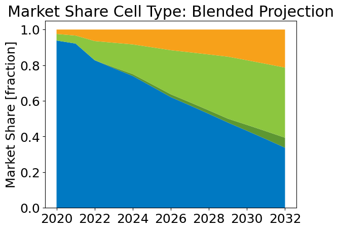

```python
plt.plot([],[],color='#0079C2', label='PERC')
plt.plot([],[],color='#5D9732', label='TOPCon (p-type)')
plt.plot([],[],color='#8CC63F', label='TOPCon (n-type)')
plt.plot([],[],color='#F7A11A', label='SHJ')
#plt.plot([],[],color='red', label='Cell')

plt.stackplot(celltech_marketshare_scaled.index,
              celltech_marketshare_scaled['p-type (PERC)'],
              celltech_marketshare_scaled['p-type (TOPCon)'],
              celltech_marketshare_scaled['n-type (TOPCon)'],
              celltech_marketshare_scaled['n-type (SHJ)'],
              colors = ['#0079C2','#5D9732','#8CC63F','#F7A11A'])

plt.title('Market Share Cell Type: Blended Projection')
plt.ylabel('Market Share [fraction]')
#plt.xlim(1995,2022)
#plt.legend(loc='lower center')
plt.rc('xtick', labelsize=16) #fontsize of the x tick labels
plt.show()
```

```python
celltech_marketshare_scaled['TOPCon'] = celltech_marketshare_scaled.filter(like='TOPCon').sum(axis=1)
```

Other Assumptions:

- silicon wafer thickness is identical, and improvements are identical
- glass-glass module package for bifacial using 2.5mm glass for both
- module manufacturing energy is identical (until we get better data)
- degradation rates between the technologies are identical (until we get better data)
- Weibull Failure probabilities are identical between technologies (until we get better data)
- No ciruclarity

```python
#glass-glass package mass per area calculation
#ITRPV 2022 Figs 36 and 38, we are assuming that the front and back glass heave equal thickness of 2.5mm
density_glass = 2500*1000 # g/m^3
glassperm2 = (2.5/1000)* 2 * density_glass
print('The mass per module area of glass is '+str(glassperm2)+' g/m^2')
```

```
The mass per module area of glass is 12500.0 g/m^2
```

Pull in deployment projection. This deployment is based on the Solar Futures report, but has been modified to be more reasonable annual deployment schedule (i.e. manufacturing ramps up). However, this does not achieve 95% RE by 2035, but it does achieve 100% RE in 2050.

```python
sf_reeds_alts = pd.read_excel(os.path.join(supportMatfolder,'SF_reeds_alternates.xlsx'),index_col=0)
```

```python
sf_reeds = sf_reeds_alts.loc[2023:2050,['MW']]
```

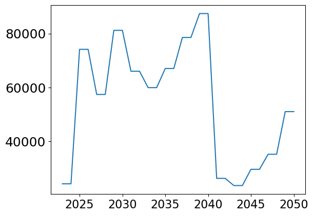

```python
plt.plot(sf_reeds)
```

```python
sf_reeds['rolling'] = sf_reeds.rolling(window=5).mean()
```

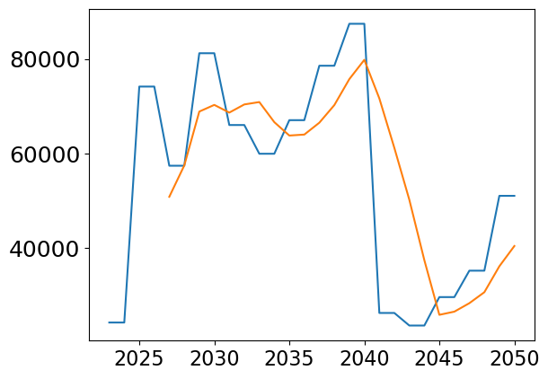

```python
plt.plot(sf_reeds)
```

```python
#try sorting the Reeds Deployment to be in ascending order
sf_reeds['MW'].values.sort() #this sorts the column values in place
```

```python
sf_reeds['TW_cum'] = sf_reeds['MW'].cumsum()/1e6
```

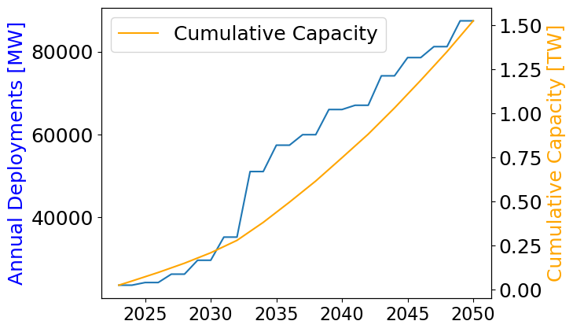

```python
fig, ax1 = plt.subplots()

ax1.plot(sf_reeds['MW'])
ax1.set_ylabel('Annual Deployments [MW]', color='blue')

ax2 = ax1.twinx()
ax2.plot(sf_reeds['TW_cum'], color='orange')
ax2.set_ylabel('Cumulative Capacity [TW]', color='orange')

#ax1.rc('xtick', labelsize=10) #fontsize of the x tick labels
#ax1.rc('ytick', labelsize=18) #fontsize of the y tick labels

plt.legend(['Cumulative Capacity'])
plt.show()
```

```python
sf_reeds.loc[2030]
```

```
MW         29613.993350
rolling    70268.932926
TW_cum         0.207411
Name: 2030.0, dtype: float64
```

```python
sf_reeds.loc[2050]
```

```
MW         87426.894740
rolling    40417.751938
TW_cum         1.523311
Name: 2050.0, dtype: float64
```

```python
#historical 2020-2022 from Wood Mac
history = sf_reeds_alts.loc[2020:2022,['Historically annual']]
history.columns=['MW']
projection = sf_reeds[['MW']]
newdeploymentcurve = pd.concat([history,projection],axis=0)
```

```python
#modify projection to be closer to global scale by x10
newdeploymentcurve_global = newdeploymentcurve*10
```

```python
newdeploymentcurve_global['TW_cum'] = newdeploymentcurve_global['MW'].cumsum()/1e6
newdeploymentcurve_global.to_csv(os.path.join(testfolder,'deploymentCurve_global.csv'))
```

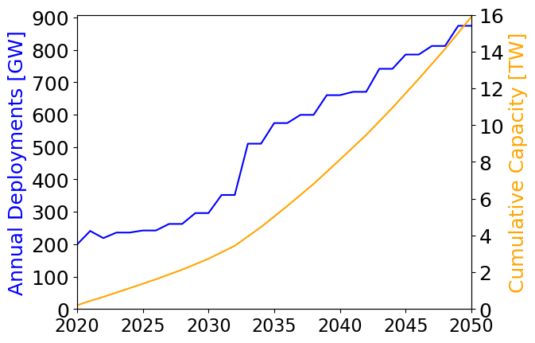

```python
fig, ax1 = plt.subplots()

ax1.plot(newdeploymentcurve_global['MW']/1000, color='blue')
ax1.set_ylabel('Annual Deployments [GW]', color='blue')
#ax1.set_ylim(0, 90)
ax1.set_yticks(range(0,901,100))
ax1.set_xlim(2020,2050)


ax2 = ax1.twinx()
ax2.plot(newdeploymentcurve_global['TW_cum'], color='orange')
ax2.set_ylabel('Cumulative Capacity [TW]', color='orange')
ax2.set_ylim(0, 16)

#plt.legend(['Cumulative Capacity'])
plt.rc('font', size=16) #controls default text size
plt.show()
```

# Scenario Creation

```python
#creating scenarios for identical power and identical area deployed
scennames = ['PERC_p','SHJ_p','TOPCon_p', 'PERC_a','SHJ_a','TOPCon_a'] #add later Blend and bifi on/off
MATERIALS = ['glass','silver','silicon', 'copper', 'aluminium_frames'] #'encapsulant', 'backsheet',
moduleFile_m = os.path.join(baselinesfolder, 'baseline_modules_mass_US.csv')
moduleFile_e = os.path.join(baselinesfolder, 'baseline_modules_energy.csv')
```

```python
#load in a baseline and materials for modification
import PV_ICE

sim1 = PV_ICE.Simulation(name='sim1', path=testfolder)
for scen in scennames:
    sim1.createScenario(name=scen, massmodulefile=moduleFile_m, energymodulefile=moduleFile_e)
    for mat in range (0, len(MATERIALS)):
        matbaseline_m = os.path.join(baselinesfolder,'baseline_material_mass_'+MATERIALS[mat]+'.csv')
        matbaseline_e = os.path.join(baselinesfolder,'baseline_material_energy_'+MATERIALS[mat]+'.csv')
        sim1.scenario[scen].addMaterial(MATERIALS[mat], massmatfile=matbaseline_m, energymatfile=matbaseline_e)
```

```
path = C:\Users\hmirletz\Documents\GitHub\PV_ICE\PV_ICE\TEMP\CellTechCompare
Making path: raw
Making path: input
Making path: output
Making path: figures
Baseline folder directed to default:  C:\Users\hmirletz\Documents\GitHub\PV_ICE\PV_ICE\baselines
```

Modify the all one tech scenarios Scenarios:

Module level

- trim to 2020-2050
- no circularity
- deployment projection
- module eff

material level

- glass per m2
- silver per m2

```python
#trim to 2020-2050, this trims module and materials
sim1.trim_Years(startYear=2020, endYear=2050)
```

[output not shown]

```python
#no circularity
sim1.scenMod_noCircularity()
```

```python
#deployment projection
#NEED TO PULL IN DEPLOYMENT PROJECTION

for scen in scennames:
    sim1.scenario[scen].dataIn_m.loc[0:len(newdeploymentcurve.index-1),'new_Installed_Capacity_[MW]'] = newdeploymentcurve_global['MW'].values
```

```python
#module eff
#modeffs
for scen in scennames:
    sim1.scenario[scen].dataIn_m.loc[0:len(modeffs.index-1),'mod_eff'] = modeffs.filter(like=str(scen[0:3])).values
```

```python
#glass modify
for scen in scennames:
    sim1.scenario[scen].material['glass'].matdataIn_m['mat_massperm2'] = glassperm2
```

```python
#silver modify
#Aguse
for scen in scennames:
    sim1.scenario[scen].material['silver'].matdataIn_m.loc[0:len(Aguse.index-1),'mat_massperm2'] = Aguse.filter(like=str(scen[0:3])).values
```

Check to make sure the modifications took.

```python
sim1.scenario['SHJ_a'].dataIn_m.head(10)
```

|  | year | new_Installed_Capacity_[MW] | mod_eff | mod_reliability_t50 | mod_reliability_t90 | mod_degradation | mod_lifetime | mod_MFG_eff | mod_Repair | mod_MerchantTail | ... | mod_EOL_pg1_landfill | mod_EOL_pg2_stored | mod_EOL_pg3_reMFG | mod_EOL_pg4_recycled | mod_EOL_reMFG_yield | mod_EOL_sp_reMFG_recycle | mod_EOL_pb1_landfill | mod_EOL_pb2_stored | mod_EOL_pb3_reMFG | mod_EOL_pb4_recycled |
| --- | --- | --- | --- | --- | --- | --- | --- | --- | --- | --- | --- | --- | --- | --- | --- | --- | --- | --- | --- | --- | --- |
| 0 | 2020 | 199145.501006 | 23.50 | 33 | 38 | 0.75 | 35.0 | 98 | 0.0 | 0.0 | ... | 100.0 | 0.0 | 0.0 | 0.0 | 0 | 0.0 | 100.0 | 0.0 | 0.0 | 0.0 |
| 1 | 2021 | 240948.044652 | 23.68 | 33 | 38 | 0.75 | 35.0 | 98 | 0.0 | 0.0 | ... | 100.0 | 0.0 | 0.0 | 0.0 | 0 | 0.0 | 100.0 | 0.0 | 0.0 | 0.0 |
| 2 | 2022 | 218931.470533 | 23.86 | 33 | 38 | 0.60 | 35.0 | 98 | 0.0 | 0.0 | ... | 100.0 | 0.0 | 0.0 | 0.0 | 0 | 0.0 | 100.0 | 0.0 | 0.0 | 0.0 |
| 3 | 2023 | 235967.289600 | 24.04 | 33 | 38 | 0.60 | 35.0 | 98 | 0.0 | 0.0 | ... | 100.0 | 0.0 | 0.0 | 0.0 | 0 | 0.0 | 100.0 | 0.0 | 0.0 | 0.0 |
| 4 | 2024 | 235967.289600 | 24.22 | 33 | 38 | 0.60 | 35.0 | 98 | 0.0 | 0.0 | ... | 100.0 | 0.0 | 0.0 | 0.0 | 0 | 0.0 | 100.0 | 0.0 | 0.0 | 0.0 |
| 5 | 2025 | 242364.159700 | 24.40 | 33 | 38 | 0.60 | 35.0 | 98 | 0.0 | 0.0 | ... | 100.0 | 0.0 | 0.0 | 0.0 | 0 | 0.0 | 100.0 | 0.0 | 0.0 | 0.0 |
| 6 | 2026 | 242364.159700 | 24.58 | 33 | 38 | 0.60 | 35.0 | 98 | 0.0 | 0.0 | ... | 100.0 | 0.0 | 0.0 | 0.0 | 0 | 0.0 | 100.0 | 0.0 | 0.0 | 0.0 |
| 7 | 2027 | 262583.013200 | 24.76 | 40 | 44 | 0.60 | 35.0 | 98 | 0.0 | 0.0 | ... | 100.0 | 0.0 | 0.0 | 0.0 | 0 | 0.0 | 100.0 | 0.0 | 0.0 | 0.0 |
| 8 | 2028 | 262583.013200 | 24.94 | 40 | 44 | 0.60 | 35.0 | 98 | 0.0 | 0.0 | ... | 100.0 | 0.0 | 0.0 | 0.0 | 0 | 0.0 | 100.0 | 0.0 | 0.0 | 0.0 |
| 9 | 2029 | 296139.933500 | 25.12 | 40 | 44 | 0.60 | 35.0 | 98 | 0.0 | 0.0 | ... | 100.0 | 0.0 | 0.0 | 0.0 | 0 | 0.0 | 100.0 | 0.0 | 0.0 | 0.0 |

10 rows × 22 columns

```python
sim1.scenario['SHJ_p'].material['silver'].matdataIn_m.head()
```

|  | year | mat_virgin_eff | mat_massperm2 | mat_MFG_eff | mat_MFG_scrap_Recycled | mat_MFG_scrap_Recycling_eff | mat_MFG_scrap_Recycled_into_HQ | mat_MFG_scrap_Recycled_into_HQ_Reused4MFG | mat_PG3_ReMFG_target | mat_ReMFG_yield | mat_PG4_Recycling_target | mat_Recycling_yield | mat_EOL_Recycled_into_HQ | mat_EOL_RecycledHQ_Reused4MFG |
| --- | --- | --- | --- | --- | --- | --- | --- | --- | --- | --- | --- | --- | --- | --- |
| 0 | 2020 | 75 | 7.911163 | 80 | 0.0 | 0.0 | 0.0 | 0.0 | 0.0 | 0 | 0.0 | 0.0 | 0.0 | 0.0 |
| 1 | 2021 | 75 | 7.479315 | 80 | 0.0 | 0.0 | 0.0 | 0.0 | 0.0 | 0 | 0.0 | 0.0 | 0.0 | 0.0 |
| 2 | 2022 | 75 | 7.047467 | 80 | 0.0 | 0.0 | 0.0 | 0.0 | 0.0 | 0 | 0.0 | 0.0 | 0.0 | 0.0 |
| 3 | 2023 | 75 | 6.615619 | 80 | 0.0 | 0.0 | 0.0 | 0.0 | 0.0 | 0 | 0.0 | 0.0 | 0.0 | 0.0 |
| 4 | 2024 | 75 | 6.183771 | 80 | 0.0 | 0.0 | 0.0 | 0.0 | 0.0 | 0 | 0.0 | 0.0 | 0.0 | 0.0 |

```python
sim1.scenario['SHJ_p'].material['silicon'].matdataIn_e.head()
```

|  | year | e_mat_extraction | e_mat_MFG | e_mat_MFG_fuelfraction | e_mat_MFGScrap_LQ | e_mat_MFGScrap_HQ | e_mat_Landfill | e_mat_Landfill_fuelfraction | e_mat_EoL_ReMFG_clean | e_mat_Recycled_LQ | e_mat_Recycled_HQ | e_mat_Recycled_HQ_fuelfraction |
| --- | --- | --- | --- | --- | --- | --- | --- | --- | --- | --- | --- | --- |
| 0 | 2020 | 0.0062 | 169.06 | 22 | 1.6 | 138.38 | 0.09 | 0 | 0.4 | 1.6 | 138.38 | 20 |
| 1 | 2021 | 0.0062 | 170.73 | 21 | 1.6 | 143.04 | 0.09 | 0 | 0.4 | 1.6 | 143.04 | 19 |
| 2 | 2022 | 0.0062 | 169.05 | 20 | 1.6 | 144.33 | 0.09 | 0 | 0.4 | 1.6 | 144.33 | 19 |
| 3 | 2023 | 0.0062 | 168.80 | 20 | 1.6 | 144.20 | 0.09 | 0 | 0.4 | 1.6 | 144.20 | 19 |
| 4 | 2024 | 0.0062 | 169.09 | 20 | 1.6 | 144.60 | 0.09 | 0 | 0.4 | 1.6 | 144.60 | 19 |

# Run Simulations

## Option 1: Compare with Idential Power Installed

```python
scennames_p = ['PERC_p','SHJ_p','TOPCon_p']
bifipaths = [bifi_perc_path,bifi_shj_path,bifi_topcon_path]
```

```python
#option 1, install identical power
sim1.calculateFlows(scenarios='PERC_p', bifacialityfactors=bifi_perc_path)
sim1.calculateFlows(scenarios='SHJ_p', bifacialityfactors=bifi_shj_path)
sim1.calculateFlows(scenarios='TOPCon_p', bifacialityfactors=bifi_topcon_path)

perc_p_yearly, perc_p_cum = sim1.aggregateResults(scenarios='PERC_p')
shj_p_yearly, shj_p_cum = sim1.aggregateResults(scenarios='SHJ_p')
topcon_p_yearly, topcon_p_cum = sim1.aggregateResults(scenarios='TOPCon_p')
```

[output not shown]

## Option 2: Compare with Idential Area Installed

```python
scennames_a = ['PERC_a','SHJ_a','TOPCon_a']
bifipaths = [bifi_perc_path,bifi_shj_path,bifi_topcon_path]
```

```python
#Calculate Area deployed based on PERC and modified SF projection above
idx_temp = Aguse.index #grab matching index
area_deploy = pd.DataFrame(index=idx_temp, dtype=float) #create an empty DF
area_deploy['Area'] = sim1.scenario['PERC_p'].dataOut_m['Area'].values
area_deploy.head()
```

|  | Area |
| --- | --- |
| 2020 | 8.163039e+08 |
| 2021 | 9.803443e+08 |
| 2022 | 8.842215e+08 |
| 2023 | 9.460754e+08 |
| 2024 | 9.392256e+08 |

```python
#option 2, install identical area
sim1.calculateFlows(scenarios='PERC_a', bifacialityfactors=bifi_perc_path, installByArea=list(area_deploy['Area']))
sim1.calculateFlows(scenarios='SHJ_a', bifacialityfactors=bifi_shj_path,  installByArea=list(area_deploy['Area']))
sim1.calculateFlows(scenarios='TOPCon_a', bifacialityfactors=bifi_topcon_path,  installByArea=list(area_deploy['Area']))

perc_a_yearly, perc_a_cum = sim1.aggregateResults(scenarios='PERC_a')
shj_a_yearly, shj_a_cum = sim1.aggregateResults(scenarios='SHJ_a')
topcon_a_yearly, topcon_a_cum = sim1.aggregateResults(scenarios='TOPCon_a')
```

[output not shown]

```python
all_results_yearly, all_results_cum = sim1.aggregateResults()
all_results_yearly.columns
```

[output not shown]

[output cut: 62 more lines]

```
Index(['VirginStock_glass_sim1_PERC_p_[Tonnes]',
       'VirginStock_silver_sim1_PERC_p_[Tonnes]',
       'VirginStock_silicon_sim1_PERC_p_[Tonnes]',
       'VirginStock_copper_sim1_PERC_p_[Tonnes]',
       'VirginStock_aluminium_frames_sim1_PERC_p_[Tonnes]',
       'VirginStock_Module_sim1_PERC_p_[Tonnes]',
       'WasteAll_glass_sim1_PERC_p_[Tonnes]',
       'WasteAll_silver_sim1_PERC_p_[Tonnes]',
       'WasteAll_silicon_sim1_PERC_p_[Tonnes]',
       'WasteAll_copper_sim1_PERC_p_[Tonnes]',
       ...
       'ActiveCapacity_sim1_SHJ_p_[MW]',
       'DecommisionedCapacity_sim1_SHJ_p_[MW]',
       'ActiveCapacity_sim1_TOPCon_p_[MW]',
       'DecommisionedCapacity_sim1_TOPCon_p_[MW]',
       'ActiveCapacity_sim1_PERC_a_[MW]',
       'DecommisionedCapacity_sim1_PERC_a_[MW]',
       'ActiveCapacity_sim1_SHJ_a_[MW]',
       'DecommisionedCapacity_sim1_SHJ_a_[MW]',
       'ActiveCapacity_sim1_TOPCon_a_[MW]',
       'DecommisionedCapacity_sim1_TOPCon_a_[MW]'],
      dtype='object', length=162)
```

### Compare Effective Capacity

```python
activecapacity_yearly_TW = pd.DataFrame(all_results_yearly.filter(like='ActiveCapacity'))/1e6
activecapacity_yearly_TW_p = activecapacity_yearly_TW.filter(like='_p')
activecapacity_yearly_TW_a = activecapacity_yearly_TW.filter(like='_a')
```

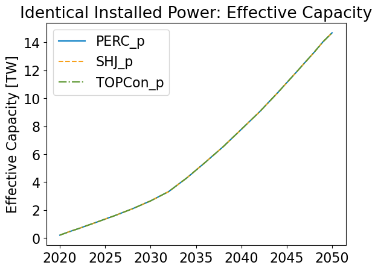

```python
plt.plot(activecapacity_yearly_TW_p.index, activecapacity_yearly_TW_p.iloc[:,[0]], color='#0079C2')
plt.plot(activecapacity_yearly_TW_p.index, activecapacity_yearly_TW_p.iloc[:,[1]], color='#F7A11A', ls='--')
plt.plot(activecapacity_yearly_TW_p.index, activecapacity_yearly_TW_p.iloc[:,[2]], color='#5D9732', ls='-.')
plt.legend(scennames_p)
plt.title('Identical Installed Power: Effective Capacity')
plt.ylabel('Effective Capacity [TW]')
```

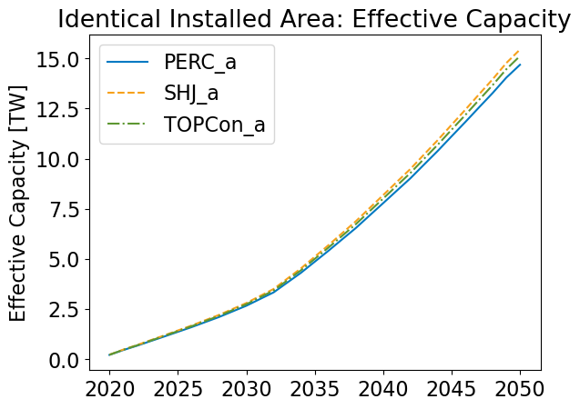

```python
plt.plot(activecapacity_yearly_TW_a.index, activecapacity_yearly_TW_a.iloc[:,[0]], color='#0079C2')
plt.plot(activecapacity_yearly_TW_a.index, activecapacity_yearly_TW_a.iloc[:,[1]], color='#F7A11A', ls='--')
plt.plot(activecapacity_yearly_TW_a.index, activecapacity_yearly_TW_a.iloc[:,[2]], color='#5D9732', ls='-.')
plt.legend(scennames_a)
plt.title('Identical Installed Area: Effective Capacity')
plt.ylabel('Effective Capacity [TW]')
```

### Compare Area Deployed

```python
#compile all energy out results
area_deployed=pd.DataFrame()
for scen in scennames:
    # add the scen name as a prefix for later filtering
    scen_area = sim1.scenario[scen].dataOut_m[['Cumulative_Active_Area']].add_prefix(str(scen+'_'))
    #concat into one large df
    area_deployed = pd.concat([area_deployed, scen_area], axis=1)

area_deployed.index = idx_temp
area_deployed.tail()
```

|  | PERC_p_Cumulative_Active_Area | SHJ_p_Cumulative_Active_Area | TOPCon_p_Cumulative_Active_Area | PERC_a_Cumulative_Active_Area | SHJ_a_Cumulative_Active_Area | TOPCon_a_Cumulative_Active_Area |
| --- | --- | --- | --- | --- | --- | --- |
| 2046 | 4.786576e+10 | 4.551035e+10 | 4.648721e+10 | 4.786576e+10 | 4.786576e+10 | 4.786576e+10 |
| 2047 | 5.086479e+10 | 4.836112e+10 | 4.939884e+10 | 5.086479e+10 | 5.086479e+10 | 5.086479e+10 |
| 2048 | 5.383243e+10 | 5.118201e+10 | 5.227991e+10 | 5.383243e+10 | 5.383243e+10 | 5.383243e+10 |
| 2049 | 5.699941e+10 | 5.419233e+10 | 5.535445e+10 | 5.699941e+10 | 5.699941e+10 | 5.699941e+10 |
| 2050 | 5.952118e+10 | 5.658818e+10 | 5.780082e+10 | 5.952118e+10 | 5.952118e+10 | 5.952118e+10 |

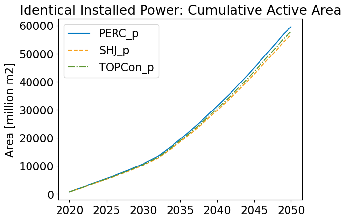

```python
plt.plot(area_deployed.index, area_deployed.iloc[:,[0]]/1e6, color='#0079C2')
plt.plot(area_deployed.index, area_deployed.iloc[:,[1]]/1e6, color='#F7A11A', ls='--')
plt.plot(area_deployed.index, area_deployed.iloc[:,[2]]/1e6, color='#5D9732', ls='-.')
plt.legend(scennames_p)
plt.title('Identical Installed Power: Cumulative Active Area')
plt.ylabel('Area [million m2]')
```

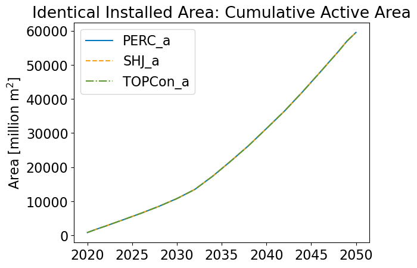

```python
plt.plot(area_deployed.index, area_deployed.iloc[:,[3]]/1e6, color='#0079C2')
plt.plot(area_deployed.index, area_deployed.iloc[:,[4]]/1e6, color='#F7A11A', ls='--')
plt.plot(area_deployed.index, area_deployed.iloc[:,[5]]/1e6, color='#5D9732', ls='-.')
plt.legend(scennames_a)
plt.title('Identical Installed Area: Cumulative Active Area')
plt.ylabel('Area [million m$^2$]')
```

## Compare Silver Demand

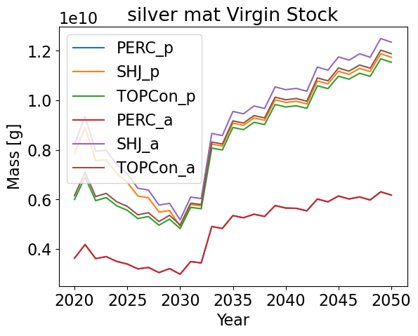

```python
sim1.plotMaterialComparisonAcrossScenarios(keyword='mat_Virgin_Stock', material='silver')
```

```python
annual_demand_silver = all_results_yearly.filter(like='VirginStock_silver')
annual_demand_silver.columns=scennames
annual_demand_silver.to_csv(os.path.join(testfolder,'annual_demand_silver.csv'))
```

```python
silver_demand_cum = pd.DataFrame(all_results_cum.filter(like='VirginStock_silver').loc[2050]).T
```

```python
silver_demand_cum
silver_demand_cum.to_csv(os.path.join(testfolder,'Ag_demand_cum2050_allScens.csv'))
```

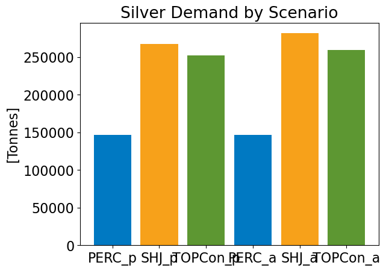

```python
plt.bar(silver_demand_cum.columns, silver_demand_cum.loc[2050], tick_label=(scennames), color=['#0079C2','#F7A11A','#5D9732'])
plt.title('Silver Demand by Scenario')
plt.ylabel('[Tonnes]')
plt.rc('xtick', labelsize=12) #fontsize of the x tick labels
```

```python
silver_demand_cum
```

|  | VirginStock_silver_sim1_PERC_p_[Tonnes] | VirginStock_silver_sim1_SHJ_p_[Tonnes] | VirginStock_silver_sim1_TOPCon_p_[Tonnes] | VirginStock_silver_sim1_PERC_a_[Tonnes] | VirginStock_silver_sim1_SHJ_a_[Tonnes] | VirginStock_silver_sim1_TOPCon_a_[Tonnes] |
| --- | --- | --- | --- | --- | --- | --- |
| 2050 | 146886.124908 | 267804.452857 | 252181.780974 | 146886.124908 | 281638.847956 | 259640.845021 |

```python
all_results_yearly.loc[2050].filter(like='newInstalledCapacity')
#FYI the area deployment doesn't overwrite the new installs column - do not trust those numbers!
```

```
newInstalledCapacity_sim1_PERC_p_[MW]      874268.9474
newInstalledCapacity_sim1_SHJ_p_[MW]       874268.9474
newInstalledCapacity_sim1_TOPCon_p_[MW]    874268.9474
newInstalledCapacity_sim1_PERC_a_[MW]      874268.9474
newInstalledCapacity_sim1_SHJ_a_[MW]       874268.9474
newInstalledCapacity_sim1_TOPCon_a_[MW]    874268.9474
Name: 2050, dtype: float64
```

```python
activecapacity = pd.DataFrame(all_results_yearly.loc[2050].filter(like='ActiveCapacity')).T/1e6
#activecapacity
newInstalledCap_TW = pd.DataFrame(all_results_yearly.loc[2050].filter(like='newInstalledCapacity')).T/1e6
newInstalledCap_TW
```

|  | newInstalledCapacity_sim1_PERC_p_[MW] | newInstalledCapacity_sim1_SHJ_p_[MW] | newInstalledCapacity_sim1_TOPCon_p_[MW] | newInstalledCapacity_sim1_PERC_a_[MW] | newInstalledCapacity_sim1_SHJ_a_[MW] | newInstalledCapacity_sim1_TOPCon_a_[MW] |
| --- | --- | --- | --- | --- | --- | --- |
| 2050 | 0.874269 | 0.874269 | 0.874269 | 0.874269 | 0.874269 | 0.874269 |

Calculate mg/W over time

```python
newInstalledCap_MW_annual = pd.DataFrame(all_results_yearly.filter(like='newInstalledCapacity'))
newInstalledCap_MW_annual.columns = scennames
```

```python
annual_demand_silver_kg = annual_demand_silver*1000
ag_annual_mgpW = annual_demand_silver_kg/newInstalledCap_MW_annual #kg/MW = mg/W
ag_annual_mgpW.loc[2050]
```

```
PERC_p       7.062816
SHJ_p       13.427981
TOPCon_p    13.200632
PERC_a       7.062816
SHJ_a       14.125632
TOPCon_a    13.595921
Name: 2050, dtype: float64
```

```python
#silver_demand_cum #tonne
newInstalledCap_MW_annual_cum = newInstalledCap_MW_annual.cumsum()
silver_demand_cum.columns
```

```
Index(['VirginStock_silver_sim1_PERC_p_[Tonnes]',
       'VirginStock_silver_sim1_SHJ_p_[Tonnes]',
       'VirginStock_silver_sim1_TOPCon_p_[Tonnes]',
       'VirginStock_silver_sim1_PERC_a_[Tonnes]',
       'VirginStock_silver_sim1_SHJ_a_[Tonnes]',
       'VirginStock_silver_sim1_TOPCon_a_[Tonnes]'],
      dtype='object')
```

```python
agintensity_mgpW = silver_demand_cum*1000/newInstalledCap_MW_annual_cum.loc[2050] #kg/MW = mg/W
agintensity_mgpW
```

|  | PERC_a | PERC_p | SHJ_a | SHJ_p | TOPCon_a | TOPCon_p | VirginStock_silver_sim1_PERC_a_[Tonnes] | VirginStock_silver_sim1_PERC_p_[Tonnes] | VirginStock_silver_sim1_SHJ_a_[Tonnes] | VirginStock_silver_sim1_SHJ_p_[Tonnes] | VirginStock_silver_sim1_TOPCon_a_[Tonnes] | VirginStock_silver_sim1_TOPCon_p_[Tonnes] |
| --- | --- | --- | --- | --- | --- | --- | --- | --- | --- | --- | --- | --- |
| 2050 | NaN | NaN | NaN | NaN | NaN | NaN | NaN | NaN | NaN | NaN | NaN | NaN |

[figure not shown]

```python
plt.bar(agintensity_mgpW.columns[0:3], agintensity_mgpW.loc[2050][0:3], color=['#0079C2','#F7A11A','#5D9732'])
plt.title('Average Silver Demand per Capacity')
plt.ylabel('mg/W')
```

# Energy Data Org

```python
#compile all energy out results
energy_mod=pd.DataFrame()
for scen in scennames:
    # add the scen name as a prefix for later filtering
    scende = sim1.scenario[scen].dataOut_e.loc[0:30].add_prefix(str(scen+'_'))
    #concat into one large df
    energy_mod = pd.concat([energy_mod, scende], axis=1)

energy_mod.tail()
```

|  | PERC_p_mod_MFG | PERC_p_mod_Install | PERC_p_mod_OandM | PERC_p_mod_Repair | PERC_p_mod_Demount | PERC_p_mod_Store | PERC_p_mod_Resell_Certify | PERC_p_mod_ReMFG_Disassembly | PERC_p_mod_Recycle_Crush | PERC_p_e_out_annual_[Wh] | ... | TOPCon_a_mod_MFG | TOPCon_a_mod_Install | TOPCon_a_mod_OandM | TOPCon_a_mod_Repair | TOPCon_a_mod_Demount | TOPCon_a_mod_Store | TOPCon_a_mod_Resell_Certify | TOPCon_a_mod_ReMFG_Disassembly | TOPCon_a_mod_Recycle_Crush | TOPCon_a_e_out_annual_[Wh] |
| --- | --- | --- | --- | --- | --- | --- | --- | --- | --- | --- | --- | --- | --- | --- | --- | --- | --- | --- | --- | --- | --- |
| 26 | 1.015141e+13 | 2.846676e+10 | 0.0 | 0.0 | 6.956768e+08 | 0.0 | 0.0 | 0.0 | 0.0 | 1.884091e+16 | ... | 1.015141e+13 | 2.846676e+10 | 0.0 | 0.0 | 6.956768e+08 | 0.0 | 0.0 | 0.0 | 0.0 | 1.958165e+16 |
| 27 | 1.049319e+13 | 2.942517e+10 | 0.0 | 0.0 | 9.343630e+08 | 0.0 | 0.0 | 0.0 | 0.0 | 2.000369e+16 | ... | 1.049319e+13 | 2.942517e+10 | 0.0 | 0.0 | 9.343630e+08 | 0.0 | 0.0 | 0.0 | 0.0 | 2.079055e+16 |
| 28 | 1.049319e+13 | 2.942517e+10 | 0.0 | 0.0 | 1.232648e+09 | 0.0 | 0.0 | 0.0 | 0.0 | 2.115051e+16 | ... | 1.049319e+13 | 2.942517e+10 | 0.0 | 0.0 | 1.232648e+09 | 0.0 | 0.0 | 0.0 | 0.0 | 2.198288e+16 |
| 29 | 1.129815e+13 | 3.168245e+10 | 0.0 | 0.0 | 1.596160e+09 | 0.0 | 0.0 | 0.0 | 0.0 | 2.237857e+16 | ... | 1.129815e+13 | 3.168245e+10 | 0.0 | 0.0 | 1.596160e+09 | 0.0 | 0.0 | 0.0 | 0.0 | 2.325969e+16 |
| 30 | 1.129815e+13 | 3.168245e+10 | 0.0 | 0.0 | 7.725603e+09 | 0.0 | 0.0 | 0.0 | 0.0 | 2.339997e+16 | ... | 1.129815e+13 | 3.168245e+10 | 0.0 | 0.0 | 7.725603e+09 | 0.0 | 0.0 | 0.0 | 0.0 | 2.432223e+16 |

5 rows × 60 columns

```python
energy_mat = pd.DataFrame()
for scen in scennames:
    for mat in MATERIALS:
        # add the scen name as a prefix for later filtering
        scenmatde = sim1.scenario[scen].material[mat].matdataOut_e.loc[0:30].add_prefix(str(scen+'_'+mat+'_'))
        #concat into one large df
        energy_mat = pd.concat([energy_mat, scenmatde], axis=1)

energy_mat.tail()
```

|  | PERC_p_glass_mat_extraction | PERC_p_glass_mat_MFG_virgin | PERC_p_glass_mat_MFG_virgin_fuel | PERC_p_glass_mat_MFGScrap_LQ | PERC_p_glass_mat_MFGScrap_HQ | PERC_p_glass_mat_MFGScrap_HQ_fuel | PERC_p_glass_mat_Landfill | PERC_p_glass_mat_Landfill_fuel | PERC_p_glass_mat_EoL_ReMFG_clean | PERC_p_glass_mat_Recycled_LQ | ... | TOPCon_a_aluminium_frames_mat_MFGScrap_LQ | TOPCon_a_aluminium_frames_mat_MFGScrap_HQ | TOPCon_a_aluminium_frames_mat_MFGScrap_HQ_fuel | TOPCon_a_aluminium_frames_mat_Landfill | TOPCon_a_aluminium_frames_mat_Landfill_fuel | TOPCon_a_aluminium_frames_mat_EoL_ReMFG_clean | TOPCon_a_aluminium_frames_mat_Recycled_LQ | TOPCon_a_aluminium_frames_mat_Recycled_HQ | TOPCon_a_aluminium_frames_mat_Recycled_HQ_fuel | TOPCon_a_aluminium_frames_mat_Recycled_HQ_elec |
| --- | --- | --- | --- | --- | --- | --- | --- | --- | --- | --- | --- | --- | --- | --- | --- | --- | --- | --- | --- | --- | --- |
| 26 | 3.989364e+11 | 1.356148e+14 | 1.177120e+14 | 0.0 | 0.0 | 0.0 | 1.859261e+11 | 1.450223e+11 | 0.0 | 0.0 | ... | 0.0 | 0.0 | 0.0 | 1.783441e+10 | 0.0 | 0.0 | 0.0 | 0.0 | 0.0 | 0.0 |
| 27 | 4.123676e+11 | 1.401807e+14 | 1.216751e+14 | 0.0 | 0.0 | 0.0 | 2.176776e+11 | 1.697885e+11 | 0.0 | 0.0 | ... | 0.0 | 0.0 | 0.0 | 2.100834e+10 | 0.0 | 0.0 | 0.0 | 0.0 | 0.0 | 0.0 |
| 28 | 4.123676e+11 | 1.401807e+14 | 1.216751e+14 | 0.0 | 0.0 | 0.0 | 2.530008e+11 | 1.973406e+11 | 0.0 | 0.0 | ... | 0.0 | 0.0 | 0.0 | 2.457003e+10 | 0.0 | 0.0 | 0.0 | 0.0 | 0.0 | 0.0 |
| 29 | 4.440014e+11 | 1.509343e+14 | 1.310091e+14 | 0.0 | 0.0 | 0.0 | 3.042588e+11 | 2.373219e+11 | 0.0 | 0.0 | ... | 0.0 | 0.0 | 0.0 | 2.965289e+10 | 0.0 | 0.0 | 0.0 | 0.0 | 0.0 | 0.0 |
| 30 | 4.440014e+11 | 1.509343e+14 | 1.310091e+14 | 0.0 | 0.0 | 0.0 | 1.030114e+12 | 8.034888e+11 | 0.0 | 0.0 | ... | 0.0 | 0.0 | 0.0 | 1.073140e+11 | 0.0 | 0.0 | 0.0 | 0.0 | 0.0 | 0.0 |

5 rows × 390 columns

```python
allenergy = pd.concat([energy_mod,energy_mat], axis=1)
allenergy.index=idx_temp
```

## Graphing Energy Generation

```python
energyGen = allenergy.filter(like='e_out_annual')
```

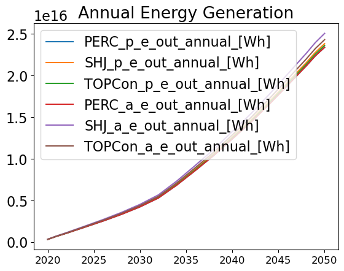

```python
fig, ax1 = plt.subplots()

ax1.plot(energyGen)
#ax1.set_ylabel('Annual Deployments [MW]', color='blue')

#ax2 = ax1.twinx()
#ax2.plot(sf_reeds['TW_cum'], color='orange')
#ax2.set_ylabel('Cumulative Capacity [TW]', color='orange')
#ax1.set_yscale('log')

plt.legend(energyGen.columns)
plt.title('Annual Energy Generation')
plt.show()
```

```python
energyGen_p = energyGen.filter(like='_p')/1e12
energyGen_a = energyGen.filter(like='_a')/1e12
```

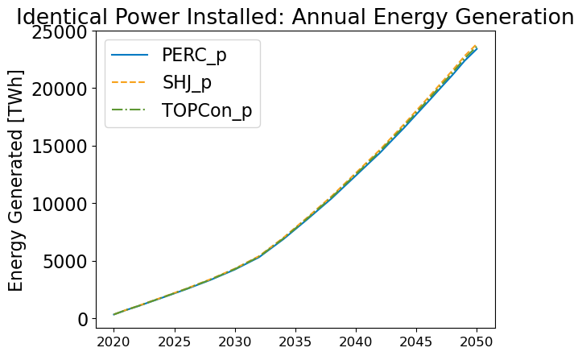

```python
#plt.plot(energyGen_p)#, color=['#006fa2','#ee005b','#734296'])
plt.plot(energyGen_p.index, energyGen_p.iloc[:,[0]], color='#0079C2')
plt.plot(energyGen_p.index, energyGen_p.iloc[:,[1]], color='#F7A11A', ls='--')
plt.plot(energyGen_p.index, energyGen_p.iloc[:,[2]], color='#5D9732', ls='-.')
plt.legend(scennames_p)
plt.title('Identical Power Installed: Annual Energy Generation')
plt.ylabel('Energy Generated [TWh]')
```

[figure not shown]

```python
#plt.plot(energyGen_p)#, color=['#006fa2','#ee005b','#734296'])
plt.plot(energyGen_a.index, energyGen_a.iloc[:,[0]], color='#0079C2')
plt.plot(energyGen_a.index, energyGen_a.iloc[:,[1]], color='#F7A11A', ls='--')
plt.plot(energyGen_a.index, energyGen_a.iloc[:,[2]], color='#5D9732', ls='-.')
plt.legend(scennames_a)
plt.title('Identical Area Installed: Annual Energy Generation')
plt.ylabel('Energy Generated [TWh]')
```

Or as a bar plot

```python
energyGen_cum = energyGen.cumsum()
energyGen_cum_2050 = energyGen_cum.loc[[2050]]
energyGen_cum_2050/1e12
energyGen_cum_2050.columns = scennames
energyGen_cum_2050
```

|  | PERC_p | SHJ_p | TOPCon_p | PERC_a | SHJ_a | TOPCon_a |
| --- | --- | --- | --- | --- | --- | --- |
| 2050 | 2.904733e+17 | 2.959027e+17 | 2.931880e+17 | 2.904733e+17 | 3.111756e+17 | 3.018223e+17 |

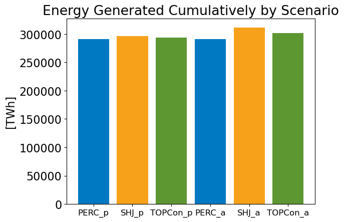

```python
plt.bar(energyGen_cum_2050.columns, energyGen_cum_2050.loc[2050]/1e12,
        tick_label=(scennames), color=['#0079C2','#F7A11A','#5D9732'])
plt.title('Energy Generated Cumulatively by Scenario')
plt.ylabel('[TWh]')
plt.rc('font', size=14) #controls default text size
plt.rc('xtick', labelsize=8) #fontsize of the x tick labels
```

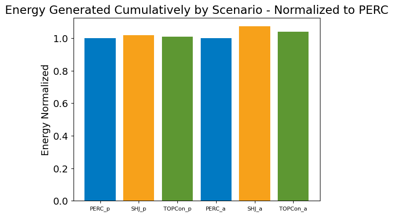

```python
energyGen_cum_2050_norm = energyGen_cum_2050/energyGen_cum_2050.loc[2050,'PERC_a']
plt.bar(energyGen_cum_2050_norm.columns, energyGen_cum_2050_norm.loc[2050], tick_label=(scennames), color=['#0079C2','#F7A11A','#5D9732'])
plt.title('Energy Generated Cumulatively by Scenario - Normalized to PERC')
plt.ylabel('Energy Normalized')
plt.rc('font', size=14) #controls default text size
plt.rc('xtick', labelsize=8) #fontsize of the x tick labels
```

```python
energyGen_cum_2050_norm
```

|  | PERC_p | SHJ_p | TOPCon_p | PERC_a | SHJ_a | TOPCon_a |
| --- | --- | --- | --- | --- | --- | --- |
| 2050 | 1.0 | 1.018692 | 1.009346 | 1.0 | 1.071271 | 1.039071 |

## Energy vs Silver Demand

```python
energyGen_cum_2050.columns=silver_demand_cum.columns=scennames
whpag = (energyGen_cum_2050)/silver_demand_cum #Wh generated cumulative, per silver demand
normalizer = whpag.loc[2050,'PERC_a']
whpag/normalizer
```

|  | PERC_p | SHJ_p | TOPCon_p | PERC_a | SHJ_a | TOPCon_a |
| --- | --- | --- | --- | --- | --- | --- |
| 2050 | 1.0 | 0.558735 | 0.587905 | 1.0 | 0.558711 | 0.587831 |

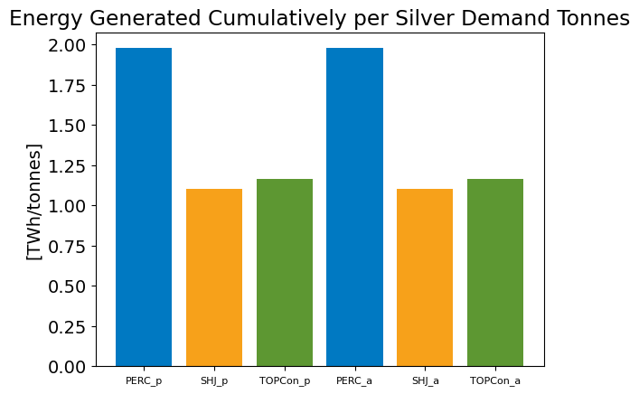

```python
plt.bar(whpag.columns, whpag.loc[2050]/1e12, tick_label=(scennames), color=['#0079C2','#F7A11A','#5D9732'])
plt.title('Energy Generated Cumulatively per Silver Demand Tonnes')
plt.ylabel('[TWh/tonnes]')
```

```python
energyGen_cum_2050.columns=silver_demand_cum.columns=scennames
agpwh= silver_demand_cum/(energyGen_cum_2050) #Wh generated cumulative, per silver demand
normalizer = agpwh.loc[2050,'PERC_a']
agpwh_norm = agpwh/normalizer
agpwh_norm
```

|  | PERC_p | SHJ_p | TOPCon_p | PERC_a | SHJ_a | TOPCon_a |
| --- | --- | --- | --- | --- | --- | --- |
| 2050 | 1.0 | 1.789758 | 1.700956 | 1.0 | 1.789833 | 1.701168 |

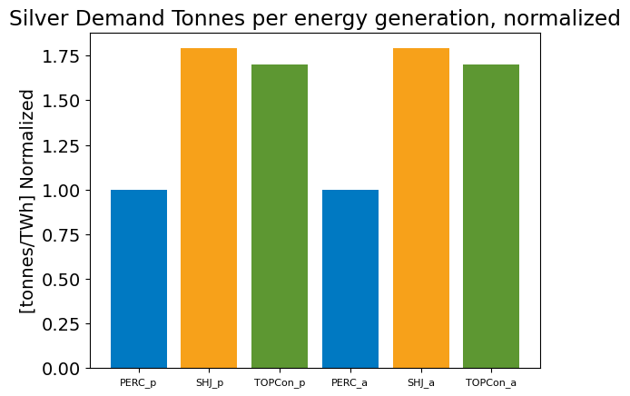

```python
plt.bar(agpwh_norm.columns, agpwh_norm.loc[2050], tick_label=(scennames), color=['#0079C2','#F7A11A','#5D9732'])
plt.title('Silver Demand Tonnes per energy generation, normalized')
plt.ylabel('[tonnes/TWh] Normalized')
```

## Net Energy Calcs

```python
#categorize the energy in values into lifecycle stages
mfg_energies = ['mod_MFG','mat_extraction','mat_MFG_virgin']
mfg_recycle_energies_LQ = ['mat_MFGScrap_LQ'] #LQ and HQ are separate becuase LQ is only LQ
mfg_recycle_energies_HQ = ['mat_MFGScrap_HQ'] #and HQ material is E_LQ + E_HQ
use_energies = ['mod_Install','mod_OandM','mod_Repair']
eol_energies = ['mat_Landfill','mod_Demount','mod_Store','mod_Resell_Certify']
eol_remfg_energies = ['mod_ReMFG_Disassmbly','mat_EoL_ReMFG_clean']
eol_recycle_energies_LQ = ['mod_Recycle_Crush','mat_Recycled_LQ']
eol_recycle_energies_HQ = ['mod_Recycle_Crush','mat_Recycled_HQ']

energy_demands_keys = [mfg_energies,mfg_recycle_energies_LQ,mfg_recycle_energies_HQ,use_energies,eol_energies,
                  eol_remfg_energies,eol_recycle_energies_LQ,eol_recycle_energies_HQ]
import itertools
energy_demands_flat = list(itertools.chain(*energy_demands_keys))
#energy_demands_flat
```

```python
#select the non energy generation columns for all scenarios
energy_demands = allenergy.loc[:,~allenergy.columns.isin(energyGen.columns)]
edemand_perc_p = energy_demands.filter(like='PERC_p')
edemand_shj_p = energy_demands.filter(like='SHJ_p')
edemand_topcon_p = energy_demands.filter(like='TOPCon_p')
edemand_perc_a = energy_demands.filter(like='PERC_a')
edemand_shj_a = energy_demands.filter(like='SHJ_a')
edemand_topcon_a = energy_demands.filter(like='TOPCon_a')
```

```python
#for each scenario, create a cumulative total energy demand
for scen in scennames:
    colname = str(scen+'_e_demand_total')
    energy_demands[colname] = energy_demands.filter(like=scen).sum(axis=1)
```

```python
energy_demands_annual = energy_demands.filter(like='e_demand_total')
yrlyedemand_perc_p = energy_demands_annual.filter(like='PERC_p')
yrlyedemand_shj_p = energy_demands_annual.filter(like='SHJ_p')
yrlyedemand_topcon_p = energy_demands_annual.filter(like='TOPCon_p')
yrlyedemand_perc_a = energy_demands_annual.filter(like='PERC_a')
yrlyedemand_shj_a = energy_demands_annual.filter(like='SHJ_a')
yrlyedemand_topcon_a = energy_demands_annual.filter(like='TOPCon_a')
```

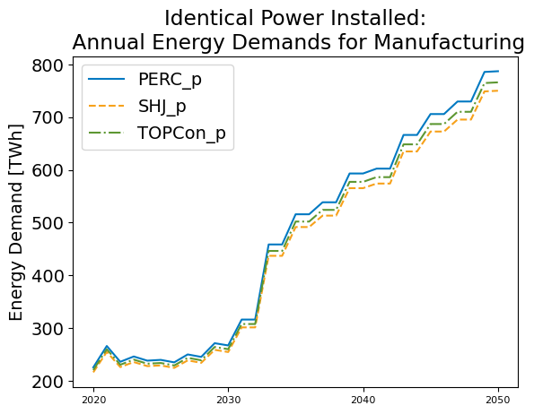

```python
#plt.plot(energy_demands_annual)
plt.plot(yrlyedemand_perc_p.index, yrlyedemand_perc_p/1e12, color='#0079C2')
plt.plot(yrlyedemand_shj_p.index, yrlyedemand_shj_p/1e12, color='#F7A11A', ls='--')
plt.plot(yrlyedemand_topcon_p.index, yrlyedemand_topcon_p/1e12, color='#5D9732', ls='-.')
plt.legend(scennames_p)
plt.title('Identical Power Installed:\n Annual Energy Demands for Manufacturing')
plt.ylabel('Energy Demand [TWh]')
plt.rc('font', size=14) #controls default text size
plt.rc('xtick', labelsize=18) #fontsize of the x tick labels
plt.show()
```

```python
energy_demand_total_cum = energy_demands.filter(like='e_demand_total').cumsum()
energy_demand_total_cum_2050 = energy_demand_total_cum.loc[[2050]]
energy_demand_total_cum_2050.columns = scennames
```

```python
energy_demand_total_cum_2050/1e12
```

|  | PERC_p | SHJ_p | TOPCon_p | PERC_a | SHJ_a | TOPCon_a |
| --- | --- | --- | --- | --- | --- | --- |
| 2050 | 14550.939525 | 13876.290691 | 14167.058521 | 14550.939525 | 14594.740909 | 14587.590311 |

```python
energy_demand_total_cum_2050/energy_demand_total_cum_2050.loc[2050,'PERC_p']
```

|  | PERC_p | SHJ_p | TOPCon_p | PERC_a | SHJ_a | TOPCon_a |
| --- | --- | --- | --- | --- | --- | --- |
| 2050 | 1.0 | 0.953635 | 0.973618 | 1.0 | 1.00301 | 1.002519 |

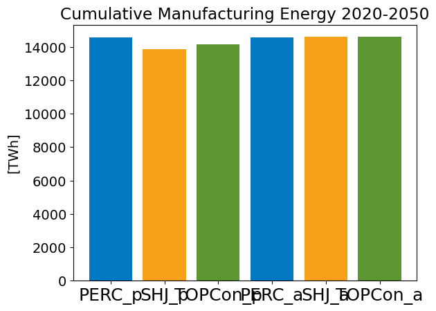

```python
plt.bar(energy_demand_total_cum_2050.columns, energy_demand_total_cum_2050.loc[2050]/1e12, tick_label=(scennames), color=['#0079C2','#F7A11A','#5D9732'])
plt.title('Cumulative Manufacturing Energy 2020-2050')
plt.ylabel('[TWh]')
```

```python
energyGen_cum_2050/1e12
```

|  | PERC_p | SHJ_p | TOPCon_p | PERC_a | SHJ_a | TOPCon_a |
| --- | --- | --- | --- | --- | --- | --- |
| 2050 | 290473.300556 | 295902.708043 | 293188.004299 | 290473.300556 | 311175.59482 | 301822.260855 |

## Net Energy

```python
net_energy_cum_2050 = (energyGen_cum_2050-energy_demand_total_cum_2050)/1e12
net_energy_cum_2050
```

|  | PERC_p | SHJ_p | TOPCon_p | PERC_a | SHJ_a | TOPCon_a |
| --- | --- | --- | --- | --- | --- | --- |
| 2050 | 275922.36103 | 282026.417352 | 279020.945778 | 275922.36103 | 296580.853911 | 287234.670544 |

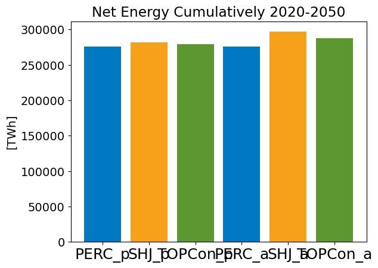

```python
plt.bar(net_energy_cum_2050.columns, net_energy_cum_2050.loc[2050], tick_label=(scennames), color=['#0079C2','#F7A11A','#5D9732'])
plt.title('Net Energy Cumulatively 2020-2050')
plt.ylabel('[TWh]')
```

```python
energyGen.columns = energy_demands_annual.columns = scennames
netEnergyAnnual_TWh = (energyGen - energy_demands_annual)/1e12
```

```python
round(netEnergyAnnual_TWh,0)
```

|  | PERC_p | SHJ_p | TOPCon_p | PERC_a | SHJ_a | TOPCon_a |
| --- | --- | --- | --- | --- | --- | --- |
| 2020 | 91.0 | 107.0 | 100.0 | 91.0 | 112.0 | 102.0 |
| 2021 | 432.0 | 457.0 | 445.0 | 432.0 | 480.0 | 457.0 |
| 2022 | 806.0 | 836.0 | 821.0 | 806.0 | 877.0 | 844.0 |
| 2023 | 1165.0 | 1202.0 | 1184.0 | 1165.0 | 1262.0 | 1216.0 |
| 2024 | 1539.0 | 1583.0 | 1561.0 | 1539.0 | 1662.0 | 1605.0 |
| 2025 | 1912.0 | 1963.0 | 1938.0 | 1912.0 | 2062.0 | 1992.0 |
| 2026 | 2289.0 | 2347.0 | 2319.0 | 2289.0 | 2465.0 | 2383.0 |
| 2027 | 2676.0 | 2742.0 | 2710.0 | 2676.0 | 2881.0 | 2786.0 |
| 2028 | 3081.0 | 3154.0 | 3118.0 | 3081.0 | 3314.0 | 3206.0 |
| 2029 | 3506.0 | 3589.0 | 3548.0 | 3506.0 | 3772.0 | 3649.0 |
| 2030 | 3958.0 | 4050.0 | 4005.0 | 3958.0 | 4256.0 | 4119.0 |
| 2031 | 4444.0 | 4548.0 | 4497.0 | 4444.0 | 4781.0 | 4626.0 |
| 2032 | 4977.0 | 5090.0 | 5035.0 | 4977.0 | 5351.0 | 5180.0 |
| 2033 | 5616.0 | 5751.0 | 5685.0 | 5616.0 | 6047.0 | 5850.0 |
| 2034 | 6394.0 | 6544.0 | 6471.0 | 6394.0 | 6880.0 | 6659.0 |
| 2035 | 7213.0 | 7381.0 | 7299.0 | 7213.0 | 7761.0 | 7512.0 |
| 2036 | 8084.0 | 8269.0 | 8178.0 | 8084.0 | 8695.0 | 8418.0 |
| 2037 | 8968.0 | 9171.0 | 9071.0 | 8968.0 | 9644.0 | 9337.0 |
| 2038 | 9870.0 | 10089.0 | 9981.0 | 9870.0 | 10610.0 | 10275.0 |
| 2039 | 10808.0 | 11049.0 | 10931.0 | 10808.0 | 11620.0 | 11253.0 |
| 2040 | 11796.0 | 12055.0 | 11928.0 | 11796.0 | 12678.0 | 12280.0 |
| 2041 | 12784.0 | 13063.0 | 12925.0 | 12784.0 | 13738.0 | 13307.0 |
| 2042 | 13775.0 | 14072.0 | 13925.0 | 13775.0 | 14799.0 | 14337.0 |
| 2043 | 14807.0 | 15127.0 | 14969.0 | 14807.0 | 15910.0 | 15412.0 |
| 2044 | 15894.0 | 16234.0 | 16066.0 | 15894.0 | 17074.0 | 16542.0 |
| 2045 | 17001.0 | 17365.0 | 17185.0 | 17001.0 | 18264.0 | 17695.0 |
| 2046 | 18135.0 | 18520.0 | 18330.0 | 18135.0 | 19479.0 | 18874.0 |
| 2047 | 19274.0 | 19682.0 | 19481.0 | 19274.0 | 20702.0 | 20059.0 |
| 2048 | 20421.0 | 20851.0 | 20638.0 | 20421.0 | 21931.0 | 21252.0 |
| 2049 | 21593.0 | 22048.0 | 21823.0 | 21593.0 | 23191.0 | 22472.0 |
| 2050 | 22613.0 | 23087.0 | 22853.0 | 22613.0 | 24284.0 | 23533.0 |

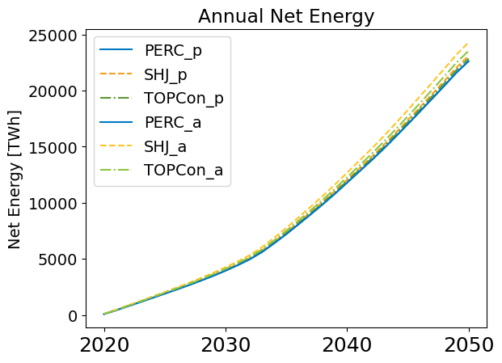

```python
fig, ax1 = plt.subplots()
#ax1.plot(netEnergyAnnual_TWh)


ax1.plot(netEnergyAnnual_TWh.index, netEnergyAnnual_TWh.iloc[:,[0]], color='#0079C2')
ax1.plot(netEnergyAnnual_TWh.index, netEnergyAnnual_TWh.iloc[:,[1]], color='#F7A11A', ls='--')
ax1.plot(netEnergyAnnual_TWh.index, netEnergyAnnual_TWh.iloc[:,[2]], color='#5D9732', ls='-.')


ax1.plot(netEnergyAnnual_TWh.index, netEnergyAnnual_TWh.iloc[:,[3]], color='#0079C2')
ax1.plot(netEnergyAnnual_TWh.index, netEnergyAnnual_TWh.iloc[:,[4]], color='#FFC423', ls='--')
ax1.plot(netEnergyAnnual_TWh.index, netEnergyAnnual_TWh.iloc[:,[5]], color='#8CC63F', ls='-.')
ax1.legend(scennames)

ax1.set_ylabel('Net Energy [TWh]')
plt.title('Annual Net Energy')
plt.show()
```

# Simulation for EROI and EBPT

Currently we dont have the ability to do cohort energy tracking. Therefore, we will test discrete points in time to evaluate a single cohort (i.e. install in only 1 year and track the energy in and out over time from that one cohort)

```python
single_deploy_2020 = pd.DataFrame(index=idx_temp, columns=['MW'], dtype=float)
single_deploy_2020['MW'] = 0.0
single_deploy_2020.loc[2020,'MW'] = 100.0
```

```python
#creating scenarios for identical power and identical area deployed
scennames2 = ['PERC','SHJ','TOPCon'] #add later Blend and bifi on/off
MATERIALS = ['glass','silver','silicon', 'copper', 'aluminium_frames'] #'encapsulant', 'backsheet',
moduleFile_m = os.path.join(baselinesfolder, 'baseline_modules_mass_US.csv')
moduleFile_e = os.path.join(baselinesfolder, 'baseline_modules_energy.csv')
```

```python
#load in a baseline and materials for modification
import PV_ICE

sim2 = PV_ICE.Simulation(name='sim1', path=testfolder)
for scen in scennames2:
    sim2.createScenario(name=scen, massmodulefile=moduleFile_m, energymodulefile=moduleFile_e)
    for mat in range (0, len(MATERIALS)):
        matbaseline_m = os.path.join(baselinesfolder,'baseline_material_mass_'+MATERIALS[mat]+'.csv')
        matbaseline_e = os.path.join(baselinesfolder,'baseline_material_energy_'+MATERIALS[mat]+'.csv')
        sim2.scenario[scen].addMaterial(MATERIALS[mat], massmatfile=matbaseline_m, energymatfile=matbaseline_e)
```

```
path = C:\Users\hmirletz\Documents\GitHub\PV_ICE\PV_ICE\TEMP\CellTechCompare
Baseline folder directed to default:  C:\Users\hmirletz\Documents\GitHub\PV_ICE\PV_ICE\baselines
```

Modify the all one tech scenarios Scenarios:

Module level

- trim to 2020-2050
- no circularity
- deployment projection
- module eff

material level

- glass per m2
- silver per m2

```python
#no circularity
sim2.scenMod_noCircularity()

#module eff
for scen in scennames2:
    sim2.scenario[scen].dataIn_m.loc[25:25+len(modeffs.index-1),'mod_eff'] = modeffs.filter(like=str(scen[0:3])).values

#glass modify
for scen in scennames2:
    sim2.scenario[scen].material['glass'].matdataIn_m['mat_massperm2'] = glassperm2

#silver modify
for scen in scennames2:
    sim2.scenario[scen].material['silver'].matdataIn_m.loc[25:25+len(Aguse.index-1),'mat_massperm2'] = Aguse.filter(like=str(scen[0:3])).values

#deployment projection
#NEED TO PULL IN DEPLOYMENT PROJECTION
for scen in scennames2:
    sim2.scenario[scen].dataIn_m.loc[25:25+len(single_deploy_2020.index-1),'new_Installed_Capacity_[MW]'] = single_deploy_2020.values

#trim to 2020-2050, this trims module and materials
sim2.trim_Years(startYear=2020, endYear=2050)
```

```
Trimming and extending  PERC
PERC glass : Data trimmed for Energy, years now encompass  2020  to  2050
PERC silver : Data trimmed for Energy, years now encompass  2020  to  2050
PERC silicon : Data trimmed for Energy, years now encompass  2020  to  2050
PERC copper : Data trimmed for Energy, years now encompass  2020  to  2050
PERC aluminium_frames : Data trimmed for Energy, years now encompass  2020  to  2050
PERC aluminium_frames : Data trimmed for Mass, years now encompass  2020  to  2050
Trimming and extending  SHJ
SHJ glass : Data trimmed for Energy, years now encompass  2020  to  2050
SHJ silver : Data trimmed for Energy, years now encompass  2020  to  2050
SHJ silicon : Data trimmed for Energy, years now encompass  2020  to  2050
SHJ copper : Data trimmed for Energy, years now encompass  2020  to  2050
SHJ aluminium_frames : Data trimmed for Energy, years now encompass  2020  to  2050
SHJ aluminium_frames : Data trimmed for Mass, years now encompass  2020  to  2050
Trimming and extending  TOPCon
TOPCon glass : Data trimmed for Energy, years now encompass  2020  to  2050
TOPCon silver : Data trimmed for Energy, years now encompass  2020  to  2050
TOPCon silicon : Data trimmed for Energy, years now encompass  2020  to  2050
TOPCon copper : Data trimmed for Energy, years now encompass  2020  to  2050
TOPCon aluminium_frames : Data trimmed for Energy, years now encompass  2020  to  2050
TOPCon aluminium_frames : Data trimmed for Mass, years now encompass  2020  to  2050
```

```python
sim2.scenario['PERC'].dataIn_e
```

|  | year | e_mod_MFG | e_mod_Install | e_mod_OandM | e_mod_Repair | e_mod_Demount | e_mod_Resell_Certify | e_mod_Store | e_mod_ReMFG_Disassembly | e_mod_Recycle_Crush |
| --- | --- | --- | --- | --- | --- | --- | --- | --- | --- | --- |
| 0 | 2020 | 3362.0 | 9.5 | 0 | 48 | 9.5 | 0.2 | 0 | 1.1 | 670 |
| 1 | 2021 | 3320.0 | 9.5 | 0 | 48 | 9.5 | 0.2 | 0 | 1.1 | 670 |
| 2 | 2022 | 3320.0 | 9.5 | 0 | 48 | 9.5 | 0.2 | 0 | 1.1 | 670 |
| 3 | 2023 | 3320.0 | 9.5 | 0 | 48 | 9.5 | 0.2 | 0 | 1.1 | 670 |
| 4 | 2024 | 3320.0 | 9.5 | 0 | 48 | 9.5 | 0.2 | 0 | 1.1 | 670 |
| 5 | 2025 | 3320.0 | 9.5 | 0 | 48 | 9.5 | 0.2 | 0 | 1.1 | 670 |
| 6 | 2026 | 3320.0 | 9.5 | 0 | 48 | 9.5 | 0.2 | 0 | 1.1 | 670 |
| 7 | 2027 | 3320.0 | 9.5 | 0 | 48 | 9.5 | 0.2 | 0 | 1.1 | 670 |
| 8 | 2028 | 3320.0 | 9.5 | 0 | 48 | 9.5 | 0.2 | 0 | 1.1 | 670 |
| 9 | 2029 | 3320.0 | 9.5 | 0 | 48 | 9.5 | 0.2 | 0 | 1.1 | 670 |
| 10 | 2030 | 3320.0 | 9.5 | 0 | 48 | 9.5 | 0.2 | 0 | 1.1 | 670 |
| 11 | 2031 | 3320.0 | 9.5 | 0 | 48 | 9.5 | 0.2 | 0 | 1.1 | 670 |
| 12 | 2032 | 3320.0 | 9.5 | 0 | 48 | 9.5 | 0.2 | 0 | 1.1 | 670 |
| 13 | 2033 | 3320.0 | 9.5 | 0 | 48 | 9.5 | 0.2 | 0 | 1.1 | 670 |
| 14 | 2034 | 3320.0 | 9.5 | 0 | 48 | 9.5 | 0.2 | 0 | 1.1 | 670 |
| 15 | 2035 | 3320.0 | 9.5 | 0 | 48 | 9.5 | 0.2 | 0 | 1.1 | 670 |
| 16 | 2036 | 3320.0 | 9.5 | 0 | 48 | 9.5 | 0.2 | 0 | 1.1 | 670 |
| 17 | 2037 | 3320.0 | 9.5 | 0 | 48 | 9.5 | 0.2 | 0 | 1.1 | 670 |
| 18 | 2038 | 3320.0 | 9.5 | 0 | 48 | 9.5 | 0.2 | 0 | 1.1 | 670 |
| 19 | 2039 | 3320.0 | 9.5 | 0 | 48 | 9.5 | 0.2 | 0 | 1.1 | 670 |
| 20 | 2040 | 3320.0 | 9.5 | 0 | 48 | 9.5 | 0.2 | 0 | 1.1 | 670 |
| 21 | 2041 | 3320.0 | 9.5 | 0 | 48 | 9.5 | 0.2 | 0 | 1.1 | 670 |
| 22 | 2042 | 3320.0 | 9.5 | 0 | 48 | 9.5 | 0.2 | 0 | 1.1 | 670 |
| 23 | 2043 | 3320.0 | 9.5 | 0 | 48 | 9.5 | 0.2 | 0 | 1.1 | 670 |
| 24 | 2044 | 3320.0 | 9.5 | 0 | 48 | 9.5 | 0.2 | 0 | 1.1 | 670 |
| 25 | 2045 | 3320.0 | 9.5 | 0 | 48 | 9.5 | 0.2 | 0 | 1.1 | 670 |
| 26 | 2046 | 3320.0 | 9.5 | 0 | 48 | 9.5 | 0.2 | 0 | 1.1 | 670 |
| 27 | 2047 | 3320.0 | 9.5 | 0 | 48 | 9.5 | 0.2 | 0 | 1.1 | 670 |
| 28 | 2048 | 3320.0 | 9.5 | 0 | 48 | 9.5 | 0.2 | 0 | 1.1 | 670 |
| 29 | 2049 | 3320.0 | 9.5 | 0 | 48 | 9.5 | 0.2 | 0 | 1.1 | 670 |
| 30 | 2050 | 3320.0 | 9.5 | 0 | 48 | 9.5 | 0.2 | 0 | 1.1 | 670 |

```python
for scen in scennames2:
    sim2.scenario[scen].dataIn_m.to_csv(os.path.join(testfolder,str('sim2_baseline_'+scen+'.csv')))
```

## 2020 Module

```python
#option 1, install identical power

sim2.calculateFlows(scenarios='PERC', bifacialityfactors=bifi_perc_path)
sim2.calculateFlows(scenarios='SHJ', bifacialityfactors=bifi_shj_path)
sim2.calculateFlows(scenarios='TOPCon', bifacialityfactors=bifi_topcon_path)

#perc_p_yearly, perc_p_cum = sim2.aggregateResults(scenarios='PERC')
#shj_p_yearly, shj_p_cum = sim2.aggregateResults(scenarios='SHJ')
#topcon_p_yearly, topcon_p_cum = sim2.aggregateResults(scenarios='TOPCon')
```

```
>>>> Calculating Material Flows <<<<

Working on Scenario:  PERC
Finished Area+Power Generation Calculations
==> Working on Material :  glass
==> Working on Material :  silver
==> Working on Material :  silicon
==> Working on Material :  copper
==> Working on Material :  aluminium_frames


>>>> Calculating Energy Flows <<<<

Working on Scenario:  PERC
==> Working on Energy for Material :  glass
==> Working on Energy for Material :  silver
==> Working on Energy for Material :  silicon
==> Working on Energy for Material :  copper
==> Working on Energy for Material :  aluminium_frames
>>>> Calculating Material Flows <<<<

Working on Scenario:  SHJ
Finished Area+Power Generation Calculations
==> Working on Material :  glass
==> Working on Material :  silver
==> Working on Material :  silicon
==> Working on Material :  copper
==> Working on Material :  aluminium_frames


>>>> Calculating Energy Flows <<<<

Working on Scenario:  SHJ
==> Working on Energy for Material :  glass
==> Working on Energy for Material :  silver
==> Working on Energy for Material :  silicon
==> Working on Energy for Material :  copper
==> Working on Energy for Material :  aluminium_frames
>>>> Calculating Material Flows <<<<

Working on Scenario:  TOPCon
Finished Area+Power Generation Calculations
==> Working on Material :  glass
==> Working on Material :  silver
==> Working on Material :  silicon
==> Working on Material :  copper
==> Working on Material :  aluminium_frames


>>>> Calculating Energy Flows <<<<

Working on Scenario:  TOPCon
==> Working on Energy for Material :  glass
==> Working on Energy for Material :  silver
==> Working on Energy for Material :  silicon
==> Working on Energy for Material :  copper
==> Working on Energy for Material :  aluminium_frames
```

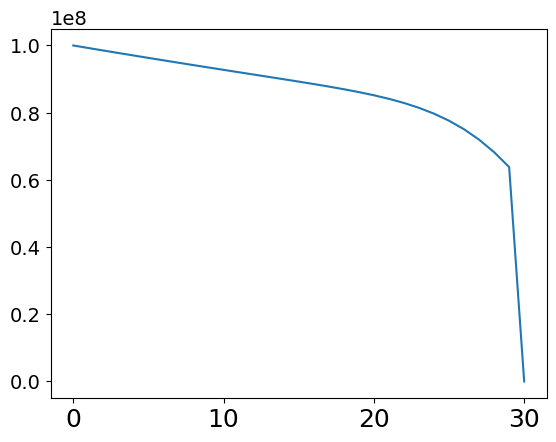

```python
plt.plot(sim2.scenario['PERC'].dataOut_m['Effective_Capacity_[W]'])
```

```python
#compile all energy out results
energy_mod2=pd.DataFrame()
for scen in scennames2:
    # add the scen name as a prefix for later filtering
    scende = sim2.scenario[scen].dataOut_e.loc[0:30].add_prefix(str(scen+'_'))
    #concat into one large df
    energy_mod2 = pd.concat([energy_mod2, scende], axis=1)

#energy_mod2.head()
```

```python
energy_mat2 = pd.DataFrame()
for scen in scennames2:
    for mat in MATERIALS:
        # add the scen name as a prefix for later filtering
        scenmatde = sim2.scenario[scen].material[mat].matdataOut_e.loc[0:30].add_prefix(str(scen+'_'+mat+'_'))
        #concat into one large df
        energy_mat2 = pd.concat([energy_mat2, scenmatde], axis=1)

#energy_mat2.tail()
```

```python
allenergy2 = pd.concat([energy_mod2,energy_mat2], axis=1)
allenergy2.index=idx_temp
```

```python
allenergy2
```

|  | PERC_mod_MFG | PERC_mod_Install | PERC_mod_OandM | PERC_mod_Repair | PERC_mod_Demount | PERC_mod_Store | PERC_mod_Resell_Certify | PERC_mod_ReMFG_Disassembly | PERC_mod_Recycle_Crush | PERC_e_out_annual_[Wh] | ... | TOPCon_silicon_mat_MFGScrap_LQ | TOPCon_silicon_mat_MFGScrap_HQ | TOPCon_silicon_mat_MFGScrap_HQ_fuel | TOPCon_silicon_mat_Landfill | TOPCon_silicon_mat_Landfill_fuel | TOPCon_silicon_mat_EoL_ReMFG_clean | TOPCon_silicon_mat_Recycled_LQ | TOPCon_silicon_mat_Recycled_HQ | TOPCon_silicon_mat_Recycled_HQ_fuel | TOPCon_silicon_mat_Recycled_HQ_elec |
| --- | --- | --- | --- | --- | --- | --- | --- | --- | --- | --- | --- | --- | --- | --- | --- | --- | --- | --- | --- | --- | --- |
| 2020 | 1.406219e+09 | 3.894081e+06 | 0.0 | 0.0 | 0.000000e+00 | 0.0 | 0.0 | 0.0 | 0.0 | 1.593444e+11 | ... | 0.0 | 0.0 | 0.0 | 7.519185e+06 | 0.0 | 0.0 | 0.0 | 0.0 | 0.0 | 0.0 |
| 2021 | 0.000000e+00 | 0.000000e+00 | 0.0 | 0.0 | 3.229504e-07 | 0.0 | 0.0 | 0.0 | 0.0 | 1.581493e+11 | ... | 0.0 | 0.0 | 0.0 | 1.178295e-06 | 0.0 | 0.0 | 0.0 | 0.0 | 0.0 | 0.0 |
| 2022 | 0.000000e+00 | 0.000000e+00 | 0.0 | 0.0 | 1.173646e-04 | 0.0 | 0.0 | 0.0 | 0.0 | 1.569632e+11 | ... | 0.0 | 0.0 | 0.0 | 4.282085e-04 | 0.0 | 0.0 | 0.0 | 0.0 | 0.0 | 0.0 |
| 2023 | 0.000000e+00 | 0.000000e+00 | 0.0 | 0.0 | 3.591049e-03 | 0.0 | 0.0 | 0.0 | 0.0 | 1.557860e+11 | ... | 0.0 | 0.0 | 0.0 | 1.310206e-02 | 0.0 | 0.0 | 0.0 | 0.0 | 0.0 | 0.0 |
| 2024 | 0.000000e+00 | 0.000000e+00 | 0.0 | 0.0 | 3.918807e-02 | 0.0 | 0.0 | 0.0 | 0.0 | 1.546176e+11 | ... | 0.0 | 0.0 | 0.0 | 1.429790e-01 | 0.0 | 0.0 | 0.0 | 0.0 | 0.0 | 0.0 |
| 2025 | 0.000000e+00 | 0.000000e+00 | 0.0 | 0.0 | 2.435910e-01 | 0.0 | 0.0 | 0.0 | 0.0 | 1.534579e+11 | ... | 0.0 | 0.0 | 0.0 | 8.887497e-01 | 0.0 | 0.0 | 0.0 | 0.0 | 0.0 | 0.0 |
| 2026 | 0.000000e+00 | 0.000000e+00 | 0.0 | 0.0 | 1.065335e+00 | 0.0 | 0.0 | 0.0 | 0.0 | 1.523070e+11 | ... | 0.0 | 0.0 | 0.0 | 3.886909e+00 | 0.0 | 0.0 | 0.0 | 0.0 | 0.0 | 0.0 |
| 2027 | 0.000000e+00 | 0.000000e+00 | 0.0 | 0.0 | 3.667219e+00 | 0.0 | 0.0 | 0.0 | 0.0 | 1.511645e+11 | ... | 0.0 | 0.0 | 0.0 | 1.337997e+01 | 0.0 | 0.0 | 0.0 | 0.0 | 0.0 | 0.0 |
| 2028 | 0.000000e+00 | 0.000000e+00 | 0.0 | 0.0 | 1.061668e+01 | 0.0 | 0.0 | 0.0 | 0.0 | 1.500304e+11 | ... | 0.0 | 0.0 | 0.0 | 3.873530e+01 | 0.0 | 0.0 | 0.0 | 0.0 | 0.0 | 0.0 |
| 2029 | 0.000000e+00 | 0.000000e+00 | 0.0 | 0.0 | 2.696454e+01 | 0.0 | 0.0 | 0.0 | 0.0 | 1.489041e+11 | ... | 0.0 | 0.0 | 0.0 | 9.838098e+01 | 0.0 | 0.0 | 0.0 | 0.0 | 0.0 | 0.0 |
| 2030 | 0.000000e+00 | 0.000000e+00 | 0.0 | 0.0 | 6.182226e+01 | 0.0 | 0.0 | 0.0 | 0.0 | 1.477850e+11 | ... | 0.0 | 0.0 | 0.0 | 2.255605e+02 | 0.0 | 0.0 | 0.0 | 0.0 | 0.0 | 0.0 |
| 2031 | 0.000000e+00 | 0.000000e+00 | 0.0 | 0.0 | 1.305563e+02 | 0.0 | 0.0 | 0.0 | 0.0 | 1.466717e+11 | ... | 0.0 | 0.0 | 0.0 | 4.763390e+02 | 0.0 | 0.0 | 0.0 | 0.0 | 0.0 | 0.0 |
| 2032 | 0.000000e+00 | 0.000000e+00 | 0.0 | 0.0 | 2.577251e+02 | 0.0 | 0.0 | 0.0 | 0.0 | 1.455620e+11 | ... | 0.0 | 0.0 | 0.0 | 9.403185e+02 | 0.0 | 0.0 | 0.0 | 0.0 | 0.0 | 0.0 |
| 2033 | 0.000000e+00 | 0.000000e+00 | 0.0 | 0.0 | 4.808870e+02 | 0.0 | 0.0 | 0.0 | 0.0 | 1.444524e+11 | ... | 0.0 | 0.0 | 0.0 | 1.754532e+03 | 0.0 | 0.0 | 0.0 | 0.0 | 0.0 | 0.0 |
| 2034 | 0.000000e+00 | 0.000000e+00 | 0.0 | 0.0 | 8.554053e+02 | 0.0 | 0.0 | 0.0 | 0.0 | 1.433376e+11 | ... | 0.0 | 0.0 | 0.0 | 3.120974e+03 | 0.0 | 0.0 | 0.0 | 0.0 | 0.0 | 0.0 |
| 2035 | 0.000000e+00 | 0.000000e+00 | 0.0 | 0.0 | 1.460363e+03 | 0.0 | 0.0 | 0.0 | 0.0 | 1.422091e+11 | ... | 0.0 | 0.0 | 0.0 | 5.328180e+03 | 0.0 | 0.0 | 0.0 | 0.0 | 0.0 | 0.0 |
| 2036 | 0.000000e+00 | 0.000000e+00 | 0.0 | 0.0 | 2.405655e+03 | 0.0 | 0.0 | 0.0 | 0.0 | 1.410553e+11 | ... | 0.0 | 0.0 | 0.0 | 8.777109e+03 | 0.0 | 0.0 | 0.0 | 0.0 | 0.0 | 0.0 |
| 2037 | 0.000000e+00 | 0.000000e+00 | 0.0 | 0.0 | 3.840263e+03 | 0.0 | 0.0 | 0.0 | 0.0 | 1.398591e+11 | ... | 0.0 | 0.0 | 0.0 | 1.401132e+04 | 0.0 | 0.0 | 0.0 | 0.0 | 0.0 | 0.0 |
| 2038 | 0.000000e+00 | 0.000000e+00 | 0.0 | 0.0 | 5.961550e+03 | 0.0 | 0.0 | 0.0 | 0.0 | 1.385972e+11 | ... | 0.0 | 0.0 | 0.0 | 2.175091e+04 | 0.0 | 0.0 | 0.0 | 0.0 | 0.0 | 0.0 |
| 2039 | 0.000000e+00 | 0.000000e+00 | 0.0 | 0.0 | 9.025173e+03 | 0.0 | 0.0 | 0.0 | 0.0 | 1.372376e+11 | ... | 0.0 | 0.0 | 0.0 | 3.292864e+04 | 0.0 | 0.0 | 0.0 | 0.0 | 0.0 | 0.0 |
| 2040 | 0.000000e+00 | 0.000000e+00 | 0.0 | 0.0 | 1.335477e+04 | 0.0 | 0.0 | 0.0 | 0.0 | 1.357382e+11 | ... | 0.0 | 0.0 | 0.0 | 4.872533e+04 | 0.0 | 0.0 | 0.0 | 0.0 | 0.0 | 0.0 |
| 2041 | 0.000000e+00 | 0.000000e+00 | 0.0 | 0.0 | 1.934993e+04 | 0.0 | 0.0 | 0.0 | 0.0 | 1.340442e+11 | ... | 0.0 | 0.0 | 0.0 | 7.059886e+04 | 0.0 | 0.0 | 0.0 | 0.0 | 0.0 | 0.0 |
| 2042 | 0.000000e+00 | 0.000000e+00 | 0.0 | 0.0 | 2.748983e+04 | 0.0 | 0.0 | 0.0 | 0.0 | 1.320857e+11 | ... | 0.0 | 0.0 | 0.0 | 1.002975e+05 | 0.0 | 0.0 | 0.0 | 0.0 | 0.0 | 0.0 |
| 2043 | 0.000000e+00 | 0.000000e+00 | 0.0 | 0.0 | 3.832860e+04 | 0.0 | 0.0 | 0.0 | 0.0 | 1.297760e+11 | ... | 0.0 | 0.0 | 0.0 | 1.398431e+05 | 0.0 | 0.0 | 0.0 | 0.0 | 0.0 | 0.0 |
| 2044 | 0.000000e+00 | 0.000000e+00 | 0.0 | 0.0 | 5.247652e+04 | 0.0 | 0.0 | 0.0 | 0.0 | 1.270103e+11 | ... | 0.0 | 0.0 | 0.0 | 1.914623e+05 | 0.0 | 0.0 | 0.0 | 0.0 | 0.0 | 0.0 |
| 2045 | 0.000000e+00 | 0.000000e+00 | 0.0 | 0.0 | 7.055873e+04 | 0.0 | 0.0 | 0.0 | 0.0 | 1.236658e+11 | ... | 0.0 | 0.0 | 0.0 | 2.574358e+05 | 0.0 | 0.0 | 0.0 | 0.0 | 0.0 | 0.0 |
| 2046 | 0.000000e+00 | 0.000000e+00 | 0.0 | 0.0 | 9.314131e+04 | 0.0 | 0.0 | 0.0 | 0.0 | 1.196045e+11 | ... | 0.0 | 0.0 | 0.0 | 3.398291e+05 | 0.0 | 0.0 | 0.0 | 0.0 | 0.0 | 0.0 |
| 2047 | 0.000000e+00 | 0.000000e+00 | 0.0 | 0.0 | 1.206133e+05 | 0.0 | 0.0 | 0.0 | 0.0 | 1.146799e+11 | ... | 0.0 | 0.0 | 0.0 | 4.400617e+05 | 0.0 | 0.0 | 0.0 | 0.0 | 0.0 | 0.0 |
| 2048 | 0.000000e+00 | 0.000000e+00 | 0.0 | 0.0 | 1.530160e+05 | 0.0 | 0.0 | 0.0 | 0.0 | 1.087484e+11 | ... | 0.0 | 0.0 | 0.0 | 5.582839e+05 | 0.0 | 0.0 | 0.0 | 0.0 | 0.0 | 0.0 |
| 2049 | 0.000000e+00 | 0.000000e+00 | 0.0 | 0.0 | 1.898185e+05 | 0.0 | 0.0 | 0.0 | 0.0 | 1.016889e+11 | ... | 0.0 | 0.0 | 0.0 | 6.925588e+05 | 0.0 | 0.0 | 0.0 | 0.0 | 0.0 | 0.0 |
| 2050 | 0.000000e+00 | 0.000000e+00 | 0.0 | 0.0 | 3.091411e+06 | 0.0 | 0.0 | 0.0 | 0.0 | 0.000000e+00 | ... | 0.0 | 0.0 | 0.0 | 1.127912e+07 | 0.0 | 0.0 | 0.0 | 0.0 | 0.0 | 0.0 |

31 rows × 147 columns

```python
perc_e_flows = allenergy2.filter(like='PERC')
perc_e_out = perc_e_flows.filter(like='e_out_annual_[Wh]')
perc_e_demand = perc_e_flows.loc[:,~perc_e_flows.columns.isin(perc_e_out.columns)]

shj_e_flows = allenergy2.filter(like='SHJ')
shj_e_out = shj_e_flows.filter(like='e_out_annual_[Wh]')
shj_e_demand = shj_e_flows.loc[:,~shj_e_flows.columns.isin(shj_e_out.columns)]

topcon_e_flows = allenergy2.filter(like='TOPCon')
topcon_e_out = topcon_e_flows.filter(like='e_out_annual_[Wh]')
topcon_e_demand = topcon_e_flows.loc[:,~topcon_e_flows.columns.isin(topcon_e_out.columns)]
```

```python
perc_e_demand_total_annual = pd.DataFrame(perc_e_demand.sum(axis=1), columns=['Wh']) #includes module and material
shj_e_demand_total_annual = pd.DataFrame(shj_e_demand.sum(axis=1), columns=['Wh']) #includes module and material
topcon_e_demand_total_annual = pd.DataFrame(topcon_e_demand.sum(axis=1), columns=['Wh']) #includes module and material
```

```python
perc_e_out.columns=perc_e_demand_total_annual.columns
perc_net_energy_annual = perc_e_out-perc_e_demand_total_annual
#perc_net_energy_annual/1e9 # GWh

shj_e_out.columns = shj_e_demand_total_annual.columns
shj_net_energy_annual = shj_e_out - shj_e_demand_total_annual
#shj_net_energy_annual/1e9 # GWh

topcon_e_out.columns=topcon_e_demand_total_annual.columns
topcon_net_energy_annual = topcon_e_out - topcon_e_demand_total_annual
#perc_net_energy_annual/1e9 # GWh
```

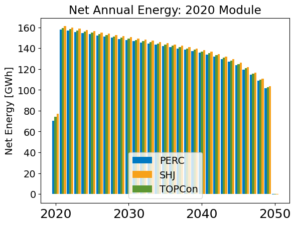

```python
width = 0.3
plt.bar(perc_net_energy_annual.index-width, perc_net_energy_annual['Wh']/1e9, width, color='#0079C2')
plt.bar(shj_net_energy_annual.index+width, shj_net_energy_annual['Wh']/1e9, width, color='#F7A11A' )
plt.bar(topcon_net_energy_annual.index, topcon_net_energy_annual['Wh']/1e9, width, color='#5D9732')

plt.legend(scennames2, loc='lower center')
plt.title('Net Annual Energy: 2020 Module')
plt.ylabel('Net Energy [GWh]')
```

```python
#EROI = Eout/Ein
perc_e_out_cum = perc_e_out.sum()
perc_e_in_cum = perc_e_demand_total_annual.sum()
EROI_perc_2020 = perc_e_out_cum[0]/perc_e_in_cum[0]
EROI_perc_2020
```

```
46.80891645795201
```

```python
shj_e_out_cum = shj_e_out.sum()
shj_e_in_cum = shj_e_demand_total_annual.sum()
EROI_shj_2020 = shj_e_out_cum[0]/shj_e_in_cum[0]
EROI_shj_2020
```

```
49.64950515419866
```

```python
topcon_e_out_cum = topcon_e_out.sum()
topcon_e_in_cum = topcon_e_demand_total_annual.sum()
EROI_topcon_2020 = topcon_e_out_cum[0]/topcon_e_in_cum[0]
EROI_topcon_2020
```

```
48.30179092309631
```

```python
eroi_2020_module = pd.DataFrame({'2020 Design':[EROI_perc_2020,EROI_shj_2020,EROI_topcon_2020]}, index=['PERC','SHJ','TOPCon'])
eroi_2020_module
```

|  | 2020 Design |
| --- | --- |
| PERC | 46.808916 |
| SHJ | 49.649505 |
| TOPCon | 48.301791 |

## 2030 Module

Grab the module properties from 2030, and deploy 100 MW for 30 yr project life

```python
idx_30_60 = pd.Series(range(2030,2061))
single_deploy_2030 = pd.DataFrame(index=idx_30_60, columns=['MW'], dtype=float)
single_deploy_2030['MW'] = 0.0
single_deploy_2030.loc[2030,'MW'] = 100.0
#single_deploy_2030
```

```python
#creating scenarios for identical power and identical area deployed
scennames3 = ['PERC','SHJ','TOPCon'] #add later Blend and bifi on/off
MATERIALS = ['glass','silver','silicon'] #, 'copper', 'encapsulant', 'backsheet', 'aluminum_frames'
moduleFile_m = os.path.join(baselinesfolder, 'baseline_modules_mass_US.csv')
moduleFile_e = os.path.join(baselinesfolder, 'baseline_modules_energy.csv')
```

```python
#load in a baseline and materials for modification
import PV_ICE

sim3 = PV_ICE.Simulation(name='sim1', path=testfolder)
for scen in scennames3:
    sim3.createScenario(name=scen, massmodulefile=moduleFile_m, energymodulefile=moduleFile_e)
    for mat in range (0, len(MATERIALS)):
        matbaseline_m = os.path.join(baselinesfolder,'baseline_material_mass_'+MATERIALS[mat]+'.csv')
        matbaseline_e = os.path.join(baselinesfolder,'baseline_material_energy_'+MATERIALS[mat]+'.csv')
        sim3.scenario[scen].addMaterial(MATERIALS[mat], massmatfile=matbaseline_m, energymatfile=matbaseline_e)
```

```
path = C:\Users\hmirletz\Documents\GitHub\PV_ICE\PV_ICE\TEMP\CellTechCompare
Baseline folder directed to default:  C:\Users\hmirletz\Documents\GitHub\PV_ICE\PV_ICE\baselines
```

Modify the all one tech scenarios Scenarios:

Module level

material level

- glass per m2
- silver per m2

```python
#no circularity
sim3.scenMod_noCircularity()

#module eff
for scen in scennames3:
    sim3.scenario[scen].dataIn_m.loc[25:25+len(modeffs.index-1),'mod_eff'] = modeffs.filter(like=str(scen[0:3])).values
    #sim1.modifyScenario('r_SHJ', 'mod_eff', celltech_modeff.loc[2022:,'SHJ'], start_year=2022) #changing module eff


#glass modify
for scen in scennames3:
    sim3.scenario[scen].material['glass'].matdataIn_m['mat_massperm2'] = glassperm2

#silver modify
for scen in scennames3:
    #sim3.scenario[scen].modifyMaterials('silver','mat_massperm2', Aguse.filter(like=str(scen[0:3])).values, start_year=2020)
    sim3.scenario[scen].material['silver'].matdataIn_m.loc[25:25+len(Aguse.index-1),'mat_massperm2'] = Aguse.filter(like=str(scen[0:3])).values
        #sim1.scenario['r_PERC'].modifyMaterials('glass', 'mat_massperm2', glassperm2, start_year=2022), celltech_aguse.loc[2022:,'SHJ']
sim3.modifyScenario(None,'new_Installed_Capacity_[MW]', value=0.0)

#trim to 2020-2050, this trims module and materials
sim3.trim_Years(startYear=2030, endYear=2100)
```

```
Trimming and extending  PERC
PERC glass : Data trimmed for Energy, years now encompass  2030  to  2100
PERC silver : Data trimmed for Energy, years now encompass  2030  to  2100
PERC silicon : Data trimmed for Energy, years now encompass  2030  to  2100
PERC silicon : Data trimmed for Mass, years now encompass  2030  to  2100
Trimming and extending  SHJ
SHJ glass : Data trimmed for Energy, years now encompass  2030  to  2100
SHJ silver : Data trimmed for Energy, years now encompass  2030  to  2100
SHJ silicon : Data trimmed for Energy, years now encompass  2030  to  2100
SHJ silicon : Data trimmed for Mass, years now encompass  2030  to  2100
Trimming and extending  TOPCon
TOPCon glass : Data trimmed for Energy, years now encompass  2030  to  2100
TOPCon silver : Data trimmed for Energy, years now encompass  2030  to  2100
TOPCon silicon : Data trimmed for Energy, years now encompass  2030  to  2100
TOPCon silicon : Data trimmed for Mass, years now encompass  2030  to  2100
```

```python
#Set 2020 module and material properties = 2030
for scen in scennames3:
    sim3.scenario[scen].dataIn_m.loc[0] = sim3.scenario[scen].dataIn_m.loc[10] #reassign row values from 2030 to 2020
    sim3.scenario[scen].dataIn_m.loc[0,'year'] = 2020 #fix the overwrite

sim3.scenario[scen].dataIn_m.tail()
```

|  | year | new_Installed_Capacity_[MW] | mod_eff | mod_reliability_t50 | mod_reliability_t90 | mod_degradation | mod_lifetime | mod_MFG_eff | mod_Repair | mod_MerchantTail | ... | mod_EOL_pg1_landfill | mod_EOL_pg2_stored | mod_EOL_pg3_reMFG | mod_EOL_pg4_recycled | mod_EOL_reMFG_yield | mod_EOL_sp_reMFG_recycle | mod_EOL_pb1_landfill | mod_EOL_pb2_stored | mod_EOL_pb3_reMFG | mod_EOL_pb4_recycled |
| --- | --- | --- | --- | --- | --- | --- | --- | --- | --- | --- | --- | --- | --- | --- | --- | --- | --- | --- | --- | --- | --- |
| 66 | 2096 | 0.0 | 25.0 | 40 | 44 | 0.5 | 35.0 | 98 | 0.0 | 0.0 | ... | 100.0 | 0.0 | 0.0 | 0.0 | 0 | 0.0 | 100.0 | 0.0 | 0.0 | 0.0 |
| 67 | 2097 | 0.0 | 25.0 | 40 | 44 | 0.5 | 35.0 | 98 | 0.0 | 0.0 | ... | 100.0 | 0.0 | 0.0 | 0.0 | 0 | 0.0 | 100.0 | 0.0 | 0.0 | 0.0 |
| 68 | 2098 | 0.0 | 25.0 | 40 | 44 | 0.5 | 35.0 | 98 | 0.0 | 0.0 | ... | 100.0 | 0.0 | 0.0 | 0.0 | 0 | 0.0 | 100.0 | 0.0 | 0.0 | 0.0 |
| 69 | 2099 | 0.0 | 25.0 | 40 | 44 | 0.5 | 35.0 | 98 | 0.0 | 0.0 | ... | 100.0 | 0.0 | 0.0 | 0.0 | 0 | 0.0 | 100.0 | 0.0 | 0.0 | 0.0 |
| 70 | 2100 | 0.0 | 25.0 | 40 | 44 | 0.5 | 35.0 | 98 | 0.0 | 0.0 | ... | 100.0 | 0.0 | 0.0 | 0.0 | 0 | 0.0 | 100.0 | 0.0 | 0.0 | 0.0 |

5 rows × 22 columns

```python
single_deploy_2020.values
```

```
array([[100.],
       [  0.],
       [  0.],
       [  0.],
       [  0.],
       [  0.],
       [  0.],
       [  0.],
       [  0.],
       [  0.],
       [  0.],
       [  0.],
       [  0.],
       [  0.],
       [  0.],
       [  0.],
       [  0.],
       [  0.],
       [  0.],
       [  0.],
       [  0.],
       [  0.],
       [  0.],
       [  0.],
       [  0.],
       [  0.],
       [  0.],
       [  0.],
       [  0.],
       [  0.],
       [  0.]])
```

```python
#deployment projection
#NEED TO PULL IN DEPLOYMENT PROJECTION
sim3.modifyScenario(scenarios=None,stage='new_Installed_Capacity_[MW]', value= single_deploy_2020.values, start_year=2020)


#for scen in scennames3:
#    sim3.scenario[scen].dataIn_m.loc[0:len(single_deploy_2020.index-1),'new_Installed_Capacity_[MW]'] = single_deploy_2020.values
```

[output not shown]

[output cut: 22 more lines]

[output not shown]

```python
sim3.scenario[scen].dataIn_m.head()
```

|  | year | new_Installed_Capacity_[MW] | mod_eff | mod_reliability_t50 | mod_reliability_t90 | mod_degradation | mod_lifetime | mod_MFG_eff | mod_Repair | mod_MerchantTail | ... | mod_EOL_pg1_landfill | mod_EOL_pg2_stored | mod_EOL_pg3_reMFG | mod_EOL_pg4_recycled | mod_EOL_reMFG_yield | mod_EOL_sp_reMFG_recycle | mod_EOL_pb1_landfill | mod_EOL_pb2_stored | mod_EOL_pb3_reMFG | mod_EOL_pb4_recycled |
| --- | --- | --- | --- | --- | --- | --- | --- | --- | --- | --- | --- | --- | --- | --- | --- | --- | --- | --- | --- | --- | --- |
| 0 | 2020 | NaN | 24.5 | 40 | 44 | 0.5 | 35.0 | 98 | 0.0 | 0.0 | ... | 100.0 | 0.0 | 0.0 | 0.0 | 0 | 0.0 | 100.0 | 0.0 | 0.0 | 0.0 |
| 1 | 2031 | NaN | 24.5 | 40 | 44 | 0.5 | 35.0 | 98 | 0.0 | 0.0 | ... | 100.0 | 0.0 | 0.0 | 0.0 | 0 | 0.0 | 100.0 | 0.0 | 0.0 | 0.0 |
| 2 | 2032 | NaN | 24.5 | 40 | 44 | 0.5 | 35.0 | 98 | 0.0 | 0.0 | ... | 100.0 | 0.0 | 0.0 | 0.0 | 0 | 0.0 | 100.0 | 0.0 | 0.0 | 0.0 |
| 3 | 2033 | NaN | 24.5 | 40 | 44 | 0.5 | 35.0 | 98 | 0.0 | 0.0 | ... | 100.0 | 0.0 | 0.0 | 0.0 | 0 | 0.0 | 100.0 | 0.0 | 0.0 | 0.0 |
| 4 | 2034 | NaN | 24.5 | 40 | 44 | 0.5 | 35.0 | 98 | 0.0 | 0.0 | ... | 100.0 | 0.0 | 0.0 | 0.0 | 0 | 0.0 | 100.0 | 0.0 | 0.0 | 0.0 |

5 rows × 22 columns

```python
#deployment projection
#NEED TO PULL IN DEPLOYMENT PROJECTION

#for scen in scennames2:
#    sim2.scenario[scen].dataIn_m.loc[0:len(single_deploy_2030.index-1),'new_Installed_Capacity_[MW]'] = single_deploy_2030.values
```

```python
#option 1, install identical power

sim3.calculateFlows(scenarios='PERC', bifacialityfactors=bifi_perc_path)
sim3.calculateFlows(scenarios='SHJ', bifacialityfactors=bifi_shj_path)
sim3.calculateFlows(scenarios='TOPCon', bifacialityfactors=bifi_topcon_path)

#perc_p_yearly, perc_p_cum = sim2.aggregateResults(scenarios='PERC')
#shj_p_yearly, shj_p_cum = sim2.aggregateResults(scenarios='SHJ')
#topcon_p_yearly, topcon_p_cum = sim2.aggregateResults(scenarios='TOPCon')
```

```python
plt.plot(sim3.scenario['PERC'].dataOut_m['Installed_Capacity_[W]'])
```

```python
#compile all energy out results
energy_mod3=pd.DataFrame()
for scen in scennames3:
    # add the scen name as a prefix for later filtering
    scende = sim3.scenario[scen].dataOut_e.loc[0:30].add_prefix(str(scen+'_'))
    #concat into one large df
    energy_mod3 = pd.concat([energy_mod3, scende], axis=1)

#energy_mod2.head()
```

```python
#compile material energy demands
energy_mat3 = pd.DataFrame()
for scen in scennames3:
    for mat in MATERIALS:
        # add the scen name as a prefix for later filtering
        scenmatde = sim3.scenario[scen].material[mat].matdataOut_e.loc[0:30].add_prefix(str(scen+'_'+mat+'_'))
        #concat into one large df
        energy_mat3 = pd.concat([energy_mat3, scenmatde], axis=1)

#energy_mat3.tail()
```

```python
allenergy3 = pd.concat([energy_mod3,energy_mat3], axis=1)
allenergy3.index=idx_30_60
```

```python
allenergy3
```

```python
perc_e_flows = allenergy3.filter(like='PERC')
perc_e_out = perc_e_flows.filter(like='e_out_annual_[Wh]')
perc_e_demand = perc_e_flows.loc[:,~perc_e_flows.columns.isin(perc_e_out.columns)]

shj_e_flows = allenergy3.filter(like='SHJ')
shj_e_out = shj_e_flows.filter(like='e_out_annual_[Wh]')
shj_e_demand = shj_e_flows.loc[:,~shj_e_flows.columns.isin(shj_e_out.columns)]

topcon_e_flows = allenergy3.filter(like='TOPCon')
topcon_e_out = topcon_e_flows.filter(like='e_out_annual_[Wh]')
topcon_e_demand = topcon_e_flows.loc[:,~topcon_e_flows.columns.isin(topcon_e_out.columns)]
```

```python
perc_e_demand_total_annual = pd.DataFrame(perc_e_demand.sum(axis=1), columns=['Wh']) #includes module and material
shj_e_demand_total_annual = pd.DataFrame(shj_e_demand.sum(axis=1), columns=['Wh']) #includes module and material
topcon_e_demand_total_annual = pd.DataFrame(topcon_e_demand.sum(axis=1), columns=['Wh']) #includes module and material
```

```python
perc_e_out.columns=perc_e_demand_total_annual.columns
perc_net_energy_annual = perc_e_out-perc_e_demand_total_annual
#perc_net_energy_annual/1e9 # GWh

shj_e_out.columns = shj_e_demand_total_annual.columns
shj_net_energy_annual = shj_e_out - shj_e_demand_total_annual
#shj_net_energy_annual/1e9 # GWh

topcon_e_out.columns=topcon_e_demand_total_annual.columns
topcon_net_energy_annual = topcon_e_out - topcon_e_demand_total_annual
#perc_net_energy_annual/1e9 # GWh
```

```python
width = 0.3
plt.bar(perc_net_energy_annual.index-width, perc_net_energy_annual['Wh']/1e9, width, color='#0079C2')
plt.bar(shj_net_energy_annual.index+width, shj_net_energy_annual['Wh']/1e9, width, color='#F7A11A' )
plt.bar(topcon_net_energy_annual.index, topcon_net_energy_annual['Wh']/1e9, width, color='#5D9732')

plt.legend(scennames2, loc='lower center')
plt.title('Net Annual Energy: 2030 Module')
plt.ylabel('Net Energy [GWh]')
```

[output not shown]

```python
#EROI = Eout/Ein
perc_e_out_cum = perc_e_out.sum()
perc_e_in_cum = perc_e_demand_total_annual.sum()
EROI_perc_2030 = perc_e_out_cum[0]/perc_e_in_cum[0]
EROI_perc_2030
```

```python
shj_e_out_cum = shj_e_out.sum()
shj_e_in_cum = shj_e_demand_total_annual.sum()
EROI_shj_2030 = shj_e_out_cum[0]/shj_e_in_cum[0]
EROI_shj_2030
```

```python
topcon_e_out_cum = topcon_e_out.sum()
topcon_e_in_cum = topcon_e_demand_total_annual.sum()
EROI_topcon_2030 = topcon_e_out_cum[0]/topcon_e_in_cum[0]
EROI_topcon_2030
```

```python
eroi_2030_module = pd.DataFrame({'2030 Design':[EROI_perc_2030,EROI_shj_2030,EROI_topcon_2030]}, index=['PERC','SHJ','TOPCon'])
eroi_2030_module
```

## 2050 Module

```python
idx_50_80 = pd.Series(range(2050,2081))
```

```python
#creating scenarios for identical power and identical area deployed
scennames4 = ['PERC','SHJ','TOPCon'] #add later Blend and bifi on/off
MATERIALS = ['glass','silver','silicon'] #, 'copper', 'encapsulant', 'backsheet', 'aluminum_frames'
moduleFile_m = os.path.join(baselinesfolder, 'baseline_modules_mass_US.csv')
moduleFile_e = os.path.join(baselinesfolder, 'baseline_modules_energy.csv')
```

```python
#load in a baseline and materials for modification
import PV_ICE

sim4 = PV_ICE.Simulation(name='sim1', path=testfolder)
for scen in scennames4:
    sim4.createScenario(name=scen, massmodulefile=moduleFile_m, energymodulefile=moduleFile_e)
    for mat in range (0, len(MATERIALS)):
        matbaseline_m = os.path.join(baselinesfolder,'baseline_material_mass_'+MATERIALS[mat]+'.csv')
        matbaseline_e = os.path.join(baselinesfolder,'baseline_material_energy_'+MATERIALS[mat]+'.csv')
        sim4.scenario[scen].addMaterial(MATERIALS[mat], massmatfile=matbaseline_m, energymatfile=matbaseline_e)
```

Modify the all one tech scenarios Scenarios:

Module level

material level

- glass per m2
- silver per m2

```python
#no circularity
sim4.scenMod_noCircularity()

#module eff
for scen in scennames4:
    sim4.scenario[scen].dataIn_m.loc[25:25+len(modeffs.index-1),'mod_eff'] = modeffs.filter(like=str(scen[0:3])).values

#glass modify
for scen in scennames4:
    sim4.scenario[scen].material['glass'].matdataIn_m['mat_massperm2'] = glassperm2

#silver modify
for scen in scennames4:
    sim4.scenario[scen].material['silver'].matdataIn_m.loc[25:25+len(Aguse.index-1),'mat_massperm2'] = Aguse.filter(like=str(scen[0:3])).values

#trim to 2020-2050, this trims module and materials
sim4.trim_Years(startYear=2020, endYear=2100)
```

```python
#Set 2020 module and material properties = 2030
for scen in scennames4:
    sim4.scenario[scen].dataIn_m.loc[0] = sim4.scenario[scen].dataIn_m.iloc[-1] #reassign row values from 2030 to 2020
    sim4.scenario[scen].dataIn_m.loc[0,'year'] = 2020 #fix the overwrite

sim4.scenario[scen].dataIn_m.head()
```

```python
#deployment projection
#NEED TO PULL IN DEPLOYMENT PROJECTION

for scen in scennames4:
    sim4.scenario[scen].dataIn_m.loc[0:len(single_deploy_2020.index-1),'new_Installed_Capacity_[MW]'] = single_deploy_2020.values
```

```python
sim4.scenario[scen].dataIn_m.head()
```

```python
#deployment projection
#NEED TO PULL IN DEPLOYMENT PROJECTION

#for scen in scennames2:
#    sim2.scenario[scen].dataIn_m.loc[0:len(single_deploy_2030.index-1),'new_Installed_Capacity_[MW]'] = single_deploy_2030.values
```

```python
#option 1, install identical power

sim4.calculateFlows(scenarios='PERC', bifacialityfactors=bifi_perc_path)
sim4.calculateFlows(scenarios='SHJ', bifacialityfactors=bifi_shj_path)
sim4.calculateFlows(scenarios='TOPCon', bifacialityfactors=bifi_topcon_path)

#perc_p_yearly, perc_p_cum = sim2.aggregateResults(scenarios='PERC')
#shj_p_yearly, shj_p_cum = sim2.aggregateResults(scenarios='SHJ')
#topcon_p_yearly, topcon_p_cum = sim2.aggregateResults(scenarios='TOPCon')
```

```python
plt.plot(sim4.scenario['PERC'].dataOut_m['Installed_Capacity_[W]'])
```

```python
#compile all energy out results
energy_mod4=pd.DataFrame()
for scen in scennames4:
    # add the scen name as a prefix for later filtering
    scende = sim4.scenario[scen].dataOut_e.loc[0:30].add_prefix(str(scen+'_'))
    #concat into one large df
    energy_mod4 = pd.concat([energy_mod4, scende], axis=1)

#energy_mod2.head()
```

```python
#compile material energy demands
energy_mat4 = pd.DataFrame()
for scen in scennames4:
    for mat in MATERIALS:
        # add the scen name as a prefix for later filtering
        scenmatde = sim4.scenario[scen].material[mat].matdataOut_e.loc[0:30].add_prefix(str(scen+'_'+mat+'_'))
        #concat into one large df
        energy_mat4 = pd.concat([energy_mat4, scenmatde], axis=1)

#energy_mat3.tail()
```

```python
allenergy4 = pd.concat([energy_mod4,energy_mat4], axis=1)
allenergy4.index=idx_50_80
```

```python
allenergy4
```

```python
perc_e_flows = allenergy4.filter(like='PERC')
perc_e_out = perc_e_flows.filter(like='e_out_annual_[Wh]')
perc_e_demand = perc_e_flows.loc[:,~perc_e_flows.columns.isin(perc_e_out.columns)]

shj_e_flows = allenergy4.filter(like='SHJ')
shj_e_out = shj_e_flows.filter(like='e_out_annual_[Wh]')
shj_e_demand = shj_e_flows.loc[:,~shj_e_flows.columns.isin(shj_e_out.columns)]

topcon_e_flows = allenergy4.filter(like='TOPCon')
topcon_e_out = topcon_e_flows.filter(like='e_out_annual_[Wh]')
topcon_e_demand = topcon_e_flows.loc[:,~topcon_e_flows.columns.isin(topcon_e_out.columns)]
```

```python
perc_e_demand_total_annual = pd.DataFrame(perc_e_demand.sum(axis=1), columns=['Wh']) #includes module and material
shj_e_demand_total_annual = pd.DataFrame(shj_e_demand.sum(axis=1), columns=['Wh']) #includes module and material
topcon_e_demand_total_annual = pd.DataFrame(topcon_e_demand.sum(axis=1), columns=['Wh']) #includes module and material
```

```python
perc_e_out.columns=perc_e_demand_total_annual.columns
perc_net_energy_annual = perc_e_out-perc_e_demand_total_annual
#perc_net_energy_annual/1e9 # GWh

shj_e_out.columns = shj_e_demand_total_annual.columns
shj_net_energy_annual = shj_e_out - shj_e_demand_total_annual
#shj_net_energy_annual/1e9 # GWh

topcon_e_out.columns=topcon_e_demand_total_annual.columns
topcon_net_energy_annual = topcon_e_out - topcon_e_demand_total_annual
#perc_net_energy_annual/1e9 # GWh
```

```python
width = 0.3
plt.bar(perc_net_energy_annual.index-width, perc_net_energy_annual['Wh']/1e9, width, color='#0079C2')
plt.bar(shj_net_energy_annual.index+width, shj_net_energy_annual['Wh']/1e9, width, color='#F7A11A' )
plt.bar(topcon_net_energy_annual.index, topcon_net_energy_annual['Wh']/1e9, width, color='#5D9732')

plt.legend(scennames2, loc='lower center')
plt.title('Net Annual Energy: 2050 Module')
plt.ylabel('Net Energy [GWh]')
```

[output not shown]

```python
#EROI = Eout/Ein
perc_e_out_cum = perc_e_out.sum()
perc_e_in_cum = perc_e_demand_total_annual.sum()
EROI_perc_2050 = perc_e_out_cum[0]/perc_e_in_cum[0]
EROI_perc_2050
```

```python
shj_e_out_cum = shj_e_out.sum()
shj_e_in_cum = shj_e_demand_total_annual.sum()
EROI_shj_2050 = shj_e_out_cum[0]/shj_e_in_cum[0]
EROI_shj_2050
```

```python
topcon_e_out_cum = topcon_e_out.sum()
topcon_e_in_cum = topcon_e_demand_total_annual.sum()
EROI_topcon_2050 = topcon_e_out_cum[0]/topcon_e_in_cum[0]
EROI_topcon_2050
```

```python
eroi_2050_module = pd.DataFrame({'2050 Design':[EROI_perc_2050,EROI_shj_2050,EROI_topcon_2050]}, index=['PERC','SHJ','TOPCon'])
eroi_2050_module
```

Normalize the EROI to PERC 2020

```python
eroi_overtime = pd.concat([eroi_2020_module,eroi_2030_module,eroi_2050_module], axis =1)
eroi_overtime
```

```python
eroi_overtime_normalized = eroi_overtime/eroi_overtime.loc['PERC','2020 Design']
eroi_overtime_normalized
```

[output not shown]

## Net Energy over Linear Mass

```python
perc_netE_cum = perc_e_out_cum-perc_e_in_cum #net energy cumulative
shj_netE_cum = shj_e_out_cum-shj_e_in_cum
topcon_netE_cum = topcon_e_out_cum-topcon_e_in_cum
netE_2050_dirty = pd.concat([perc_netE_cum,shj_netE_cum,topcon_netE_cum], axis=0, keys=['PERC','SHJ','TOPCon'])
netE_2050 = netE_2050_dirty.droplevel(1)
```

```python
netE_2050_gwh = netE_2050/1e9
netE_2050_gwh
```

```python
mod2050_mass_yearly, mod2050_mass_cum = sim4.aggregateResults()
```

```python
vstock_allmod_2050design = mod2050_mass_cum.loc[2050].filter(like='VirginStock_Module')
vstock_allmod_2050design.index = ['PERC','SHJ','TOPCon']
lwaste_allmod_2050design = mod2050_mass_cum.loc[2050].filter(like='WasteAll_Module')
lwaste_allmod_2050design.index = ['PERC','SHJ','TOPCon']
```

```python
linMass2050 = vstock_allmod_2050design+lwaste_allmod_2050design
linMass2050
```

```python
metric_2050mod = netE_2050_gwh/linMass2050
```

```python
metric_2050mod/metric_2050mod['PERC']
```

## Manufacturing Energy of One module each year

Assuming a 2.0 m^2 module

```python
scennames_anModule = ['PERC_anModule','SHJ_anModule','TOPCon_anModule']
bifipaths = [bifi_perc_path,bifi_shj_path,bifi_topcon_path]
```

```python
#create an area dataframe to feed in a module each year
idx_temp = Aguse.index #grab matching index
area_deploy_anModule = pd.DataFrame(index=idx_temp, dtype=float) #create an empty DF
area_deploy_anModule['Area'] = 2.0
area_deploy_anModule.head()
```

```python
#creating scenarios for identical power and identical area deployed
MATERIALS = ['glass','silver','silicon', 'copper', 'aluminium_frames'] # 'encapsulant', 'backsheet',
moduleFile_m = os.path.join(baselinesfolder, 'baseline_modules_mass_US.csv')
moduleFile_e = os.path.join(baselinesfolder, 'baseline_modules_energy.csv')
```

```python
#load in a baseline and materials for modification
import PV_ICE

sim_anModule = PV_ICE.Simulation(name='sim_anModule', path=testfolder)
for scen in scennames_anModule:
    sim_anModule.createScenario(name=scen, massmodulefile=moduleFile_m, energymodulefile=moduleFile_e)
    for mat in range (0, len(MATERIALS)):
        matbaseline_m = os.path.join(baselinesfolder,'baseline_material_mass_'+MATERIALS[mat]+'.csv')
        matbaseline_e = os.path.join(baselinesfolder,'baseline_material_energy_'+MATERIALS[mat]+'.csv')
        sim_anModule.scenario[scen].addMaterial(MATERIALS[mat], massmatfile=matbaseline_m, energymatfile=matbaseline_e)
```

Modify the all one tech scenarios Scenarios:

Module level

material level

- glass per m2
- silver per m2

```python
len(modeffs)
```

```python
#no circularity
sim_anModule.scenMod_noCircularity()

#module eff
for scen in scennames_anModule:
    sim_anModule.scenario[scen].dataIn_m.loc[0:len(modeffs.index-1),'mod_eff'] = modeffs.filter(like=str(scen[0:3])).values

#glass modify
for scen in scennames_anModule:
    sim_anModule.scenario[scen].material['glass'].matdataIn_m['mat_massperm2'] = glassperm2

#silver modify
for scen in scennames_anModule:
    sim_anModule.scenario[scen].material['silver'].matdataIn_m.loc[0:len(Aguse.index-1),'mat_massperm2'] = Aguse.filter(like=str(scen[0:3])).values

#trim to 2020-2050, this trims module and materials
sim_anModule.trim_Years(startYear=2020, endYear=2100)
```

```python
#option 1, install identical power
sim_anModule.calculateFlows(scenarios='PERC_anModule', bifacialityfactors=bifi_perc_path, installByArea=list(area_deploy_anModule['Area']))
sim_anModule.calculateFlows(scenarios='SHJ_anModule', bifacialityfactors=bifi_shj_path,  installByArea=list(area_deploy_anModule['Area']))
sim_anModule.calculateFlows(scenarios='TOPCon_anModule', bifacialityfactors=bifi_topcon_path,  installByArea=list(area_deploy_anModule['Area']))

perc_anModule_yearly, perc_anModule_cum = sim_anModule.aggregateResults(scenarios='PERC_anModule')
shj_anModule_yearly, shj_anModule_cum = sim_anModule.aggregateResults(scenarios='SHJ_anModule')
topcon_anModule_yearly, topcon_anModule_cum = sim_anModule.aggregateResults(scenarios='TOPCon_anModule')
```

```python
anModule_yearly, anModule_cum = sim_anModule.aggregateResults()
anModule_yearly.columns
```

```python
#compile all energy out results
energy_anModule=pd.DataFrame()
for scen in scennames_anModule:
    # add the scen name as a prefix for later filtering
    scende = sim_anModule.scenario[scen].dataOut_e.loc[0:30].add_prefix(str(scen+'_'))
    #concat into one large df
    energy_anModule = pd.concat([energy_anModule, scende], axis=1)

energy_anModule.tail()
```

```python
energy_mat_anModule = pd.DataFrame()
for scen in scennames_anModule:
    for mat in MATERIALS:
        # add the scen name as a prefix for later filtering
        scenmatde = sim_anModule.scenario[scen].material[mat].matdataOut_e.loc[0:30].add_prefix(str(scen+'_'+mat+'_'))
        #concat into one large df
        energy_mat_anModule = pd.concat([energy_mat_anModule, scenmatde], axis=1)

energy_mat_anModule.tail()
```

```python
allenergy_anModule = pd.concat([energy_anModule,energy_mat_anModule], axis=1)
allenergy_anModule.index=idx_temp
```

```python
remove = allenergy_anModule.filter(like='e_out_annual').columns
energy_demand_anModule = allenergy_anModule.drop(columns=remove)
```

```python
energy_demand_anModule_perc = energy_demand_anModule.filter(like='PERC')
energy_demand_anModule_shj = energy_demand_anModule.filter(like='SHJ')
energy_demand_anModule_topcon = energy_demand_anModule.filter(like='TOPCon')
```

```python
energy_demand_anModule_perc_cum = pd.DataFrame(energy_demand_anModule_perc.sum(axis=1), columns=['E_mfg_anModule_[Wh]'])
energy_demand_anModule_shj_cum = pd.DataFrame(energy_demand_anModule_shj.sum(axis=1), columns=['E_mfg_anModule_[Wh]'])
energy_demand_anModule_topcon_cum = pd.DataFrame(energy_demand_anModule_topcon.sum(axis=1), columns=['E_mfg_anModule_[Wh]'])
mfg_anModule = pd.concat([energy_demand_anModule_perc_cum,energy_demand_anModule_shj_cum,energy_demand_anModule_topcon_cum], axis=1)
mfg_anModule.columns = scennames_anModule
```

```python
fig, ax1 = plt.subplots()
#ax1.plot(netEnergyAnnual_TWh)


ax1.plot(energy_demand_anModule_perc_cum/1e6, color='#0079C2')
ax1.plot(energy_demand_anModule_shj_cum/1e6, color='#F7A11A', ls='--')
ax1.plot(energy_demand_anModule_topcon_cum/1e6, color='#5D9732', ls='-.')

plt.legend(scennames)
#ax1.set_yscale('log')
ax1.set_ylabel('Manufacturing Energy [MWh/module]')
plt.title('Manufacturing Energy by Technology over Time')
plt.rc('font', size=18) #controls default text size
plt.show()
```

```python
#mfg_anModule
#shows that they are in fact slightly different energy demands between technologies.
#lets divide by PERC and see % wise how different.
mfg_anModule_normalized = mfg_anModule.iloc[:,[0,1,2]]/mfg_anModule.iloc[:,[0]].values
mfg_anModule_normalized#.loc[[2050]]
```

separate out by module vs material energy demand

```python
energy_mat_anModule_perc_glass = energy_mat_anModule.filter(like='PERC').filter(like='glass')
energy_mat_anModule_perc_si = energy_mat_anModule.filter(like='PERC').filter(like='silicon')
energy_mat_anModule_perc_ag = energy_mat_anModule.filter(like='PERC').filter(like='silver')

energy_anModule_perc_mod_temp = energy_anModule.filter(like='PERC')
remove_1 = energy_anModule.filter(like='PERC').filter(like='e_out').columns
energy_anModule_perc_mod = energy_anModule_perc_mod_temp.drop(columns=remove_1)
```

```python
emod = energy_anModule_perc_mod.sum(axis=1)
eglass = energy_mat_anModule_perc_glass.sum(axis=1)
esi = energy_mat_anModule_perc_si.sum(axis=1)
eag = energy_mat_anModule_perc_ag.sum(axis=1)
e_bkdwn_mod_mat = pd.concat([emod,eglass,esi,eag], axis=1, keys=['mod','glass','silicon','silver'])
```

```python
e_bkdwn_mod_mat
```

```python
plt.plot(e_bkdwn_mod_mat/1e6)
plt.legend(e_bkdwn_mod_mat.columns)
plt.title('PERC MFGing energy Demands by component')
plt.ylabel('Manufacturing Energy [MWh/module]')
```

```python
energy_mat_anModule_shj_glass = energy_mat_anModule.filter(like='SHJ').filter(like='glass')
energy_mat_anModule_shj_si = energy_mat_anModule.filter(like='SHJ').filter(like='silicon')
energy_mat_anModule_shj_ag = energy_mat_anModule.filter(like='SHJ').filter(like='silver')

energy_anModule_shj_mod_temp = energy_anModule.filter(like='SHJ')
remove_1 = energy_anModule.filter(like='SHJ').filter(like='e_out').columns
energy_anModule_shj_mod = energy_anModule_shj_mod_temp.drop(columns=remove_1)
```

```python
emod_shj = energy_anModule_shj_mod.sum(axis=1)
eglass_shj = energy_mat_anModule_shj_glass.sum(axis=1)
esi_shj = energy_mat_anModule_shj_si.sum(axis=1)
eag_shj = energy_mat_anModule_shj_ag.sum(axis=1)
e_bkdwn_mod_mat_shj = pd.concat([emod_shj,eglass_shj,esi_shj,eag_shj], axis=1, keys=['module','glass','silicon','silver'])
idx_20_50 = pd.Series(range(2020,2051))
e_bkdwn_mod_mat_shj.index=idx_20_50
```

```python
e_bkdwn_mod_mat_shj
```

```python
fig, ax = plt.subplots()

ax.bar(e_bkdwn_mod_mat_shj.index, e_bkdwn_mod_mat_shj['module']/1e6, label='module', color='slategray')
ax.bar(e_bkdwn_mod_mat_shj.index, e_bkdwn_mod_mat_shj['glass']/1e6, label='glass', color = 'lightskyblue',
       bottom=e_bkdwn_mod_mat_shj['module']/1e6)
ax.bar(e_bkdwn_mod_mat_shj.index, e_bkdwn_mod_mat_shj['silicon']/1e6, label='silicon', color='cornflowerblue',
       bottom=(e_bkdwn_mod_mat_shj['module']+e_bkdwn_mod_mat_shj['glass'])/1e6)
ax.bar(e_bkdwn_mod_mat_shj.index, e_bkdwn_mod_mat_shj['silver']/1e6, label='silver', color = 'navy',
       bottom=(e_bkdwn_mod_mat_shj['module']+e_bkdwn_mod_mat_shj['glass']+e_bkdwn_mod_mat_shj['silicon'])/1e6)

plt.legend(loc='lower center')
ax.set_ylabel('Energy Demand [MWh/module]')
plt.title('Change in Manufacturing Energy by Component: SHJ')
plt.rc('font', size=14) #controls default text size
plt.show()
```

```python
# create an agg Energy Results based on agg mass results
    def aggregateResults_e(self, scenarios=None, materials=None):

        if scenarios is None:
            scenarios = list(self.scenario.keys())
        else:
            if isinstance(scenarios, str):
                scenarios = [scenarios]

        if materials is None:
            materials = list(self.scenario[scenarios[0]].material.keys())
        else:
            if isinstance(materials, str):
                materials = [materials]

        keywds = ['mat_Virgin_Stock', 'mat_Total_Landfilled', 'mat_Total_EOL_Landfilled', 'mat_Total_MFG_Landfilled']
        nice_keywds = ['VirginStock', 'WasteAll', 'WasteEOL', 'WasteMFG']

        USyearly=pd.DataFrame()

        for scen in scenarios:
            for ii in range(len(keywds)):
                keywd = keywds[ii]
                nicekey = nice_keywds[ii]

                for mat in materials:
                    USyearly[nicekey+'_'+mat+'_'+self.name+'_'+scen] = self.scenario[scen].material[mat].matdataOut_m[keywd]
                filter_col = [col for col in USyearly if (col.startswith(nicekey) and col.endswith(self.name+'_'+scen)) ]
                USyearly[nicekey+'_Module_'+self.name+'_'+scen] = USyearly[filter_col].sum(axis=1)
                # 2DO: Add multiple objects option


        USyearly = USyearly/1000000  # This is the ratio for grams to Metric tonnes
        USyearly = USyearly.add_suffix('_[Tonnes]')

        # Different units, so no need to do the ratio to Metric tonnes :p
        keywd1='new_Installed_Capacity_[MW]'

        for scen in scenarios:
            USyearly['newInstalledCapacity_'+self.name+'_'+scen+'_[MW]'] = self.scenario[scen].dataIn_m[keywd1]

        # Creating c umulative results
        UScum = USyearly.copy()
        UScum = UScum.cumsum()

        # Adding Installed Capacity to US (This is already 'Cumulative') so not including it in UScum
        # We are also renaming it to 'ActiveCapacity' and calculating Decommisioned Capacity.
        # TODO: Rename Installed_CApacity to ActiveCapacity throughout.
        keywd='Installed_Capacity_[W]'
        for scen in scenarios:
            USyearly['ActiveCapacity_'+self.name+'_'+scen+'_[MW]'] = self.scenario[scen].dataOut_m[keywd]/1e6
            USyearly['DecommisionedCapacity_'+self.name+'_'+scen+'_[MW]'] = (
                UScum['newInstalledCapacity_'+self.name+'_'+scen+'_[MW]']-
                USyearly['ActiveCapacity_'+self.name+'_'+scen+'_[MW]'])

        # Adding Decommissioned Capacity

        # Reindexing and Merging
        USyearly.index = self.scenario[scen].dataIn_m['year']
        UScum.index = self.scenario[scen].dataIn_m['year']

        self.USyearly = USyearly
        self.UScum = UScum

        return USyearly, UScum
```